# Analyse statistique avec R

### Featuring

#### Missing

```r
lieux <- lieux %>% mutate_all(~ifelse(. == 'N/A', NA, .))
lieux <- lieux %>% mutate_all(~ifelse(. == '-1', NA, .))
lieux <- lieux %>% mutate_all(~ifelse(. == -1, NA, .))
lieux %>% get_missing() %>% render_df()
```

|  | variable | dtype | count | unique | missing | missing_prop |
| --- | --- | --- | --- | --- | --- | --- |
| Num_Acc | Num_Acc | numeric | 56518 | 56518 | 0 | 0.00 |
| catr | catr | integer | 56518 | 8 | 0 | 0.00 |
| voie | voie | character | 56518 | 17263 | 4407 | 7.80 |
| v1 | v1 | integer | 56518 | 3 | 9823 | 17.38 |
| v2 | v2 | character | 56518 | 26 | 51528 | 91.17 |
| circ | circ | integer | 56518 | 4 | 3238 | 5.73 |
| nbv | nbv | integer | 56518 | 13 | 559 | 0.99 |
| vosp | vosp | integer | 56518 | 4 | 210 | 0.37 |
| prof | prof | integer | 56518 | 4 | 12 | 0.02 |
| pr | pr | character | 56518 | 457 | 0 | 0.00 |
| pr1 | pr1 | character | 56518 | 1133 | 0 | 0.00 |
| plan | plan | integer | 56518 | 4 | 13 | 0.02 |
| lartpc | lartpc | numeric | 56518 | 19 | 56410 | 99.81 |
| larrout | larrout | numeric | 56518 | 86 | 53810 | 95.21 |
| surf | surf | integer | 56518 | 9 | 14 | 0.02 |
| infra | infra | integer | 56518 | 10 | 619 | 1.10 |
| situ | situ | integer | 56518 | 7 | 8 | 0.01 |
| vma | vma | integer | 56518 | 36 | 875 | 1.55 |

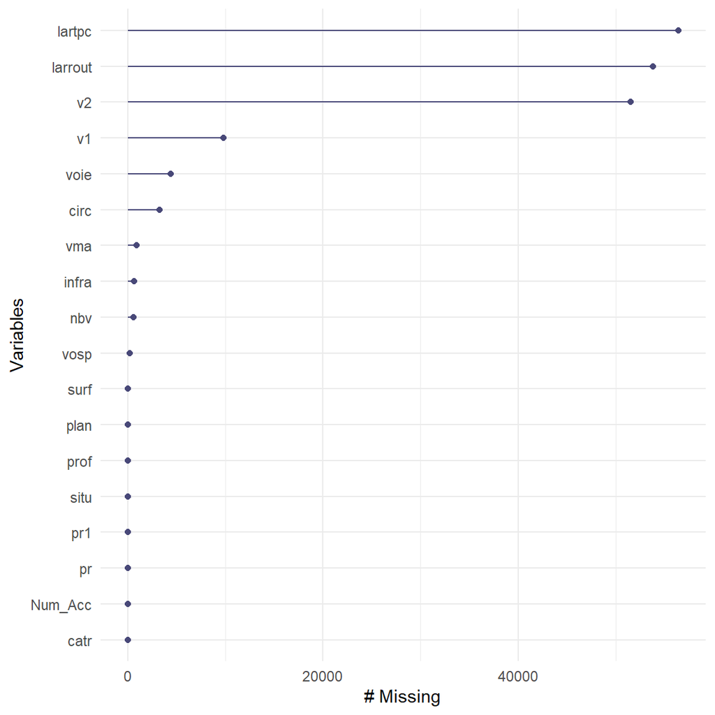

```r
lieux %>% gg_miss_var()
```

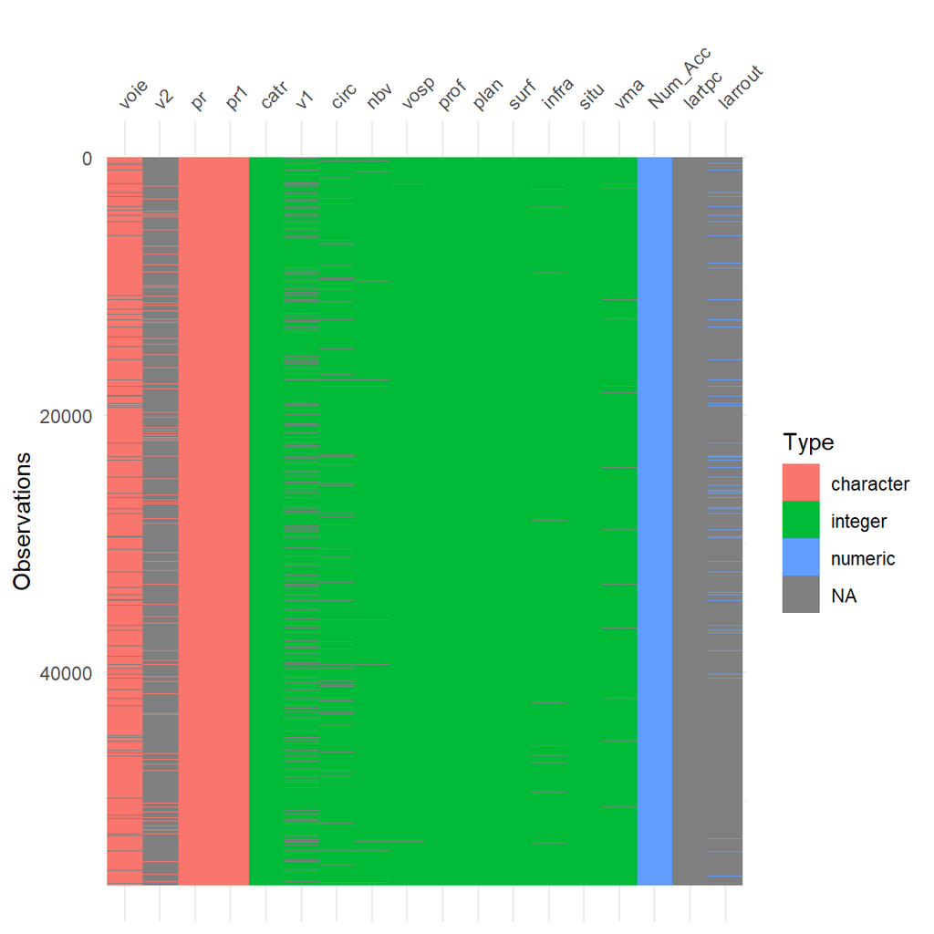

```r
lieux %>% vis_dat(warn_large_data=FALSE)
```

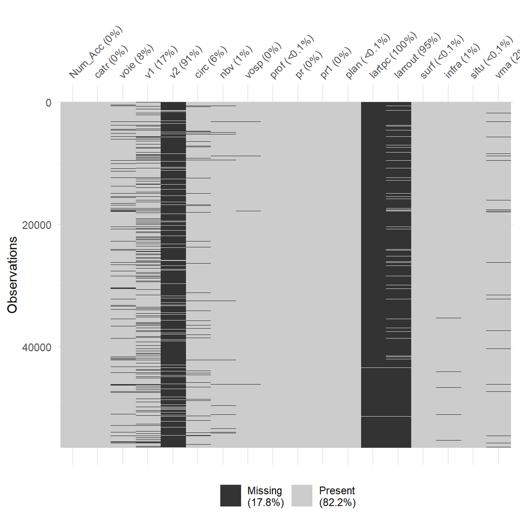

```r
lieux %>% vis_miss(warn_large_data=FALSE)
```

#### Engineering

```r
lieux <- lieux %>%
  mutate(surf, surf_gr = if_else(surf==1, "normale", "risquée")) %>%
  mutate(vma = replace(vma, (vma < 10 | vma > 130), NA)) %>%
  mutate(prof, prof_gr = if_else(prof == 1, 'plat', 'pente/cote')) %>%
  mutate(plan, plan_gr = if_else(plan ==1 , 'rectiligne', 'courbe')) %>%
  mutate(infra, infrastructure = if_else(infra == 0, 'non', 'oui'))
```

#### Setting

```r
strings <- list(
  'Num_Acc' # keep for join
)
numericals <- list(
  "nbv", #histogram ok pour le considerer en num
  "vma"
)
factors <- list(
  "circ",
  "prof_gr",
  "plan_gr",
  "surf_gr",
  "infrastructure"
)
to_drop <- list(
  "larrout", # 95% missing
  "lartpc", # 99% missing
  "voie", # irrelevant
  "pr", # irrelevant
  "pr1", #irrelevant
  "v1", # irrelevant
  "v2", # irrelevant
  "surf", #surf_gr instead
  "catr",
  "vosp",
  "prof",
  "plan",
  "infra",
  "situ"
  )

lieux <- lieux %>% set_data(numericals, factors, strings)
lieux <- lieux %>% del_vars(to_drop)
```

### Summary

#### head

```r
lieux %>% head() %>% render_df()
```

| Num_Acc | circ | nbv | vma | surf_gr | prof_gr | plan_gr | infrastructure |
| --- | --- | --- | --- | --- | --- | --- | --- |
| 202100000001 | 2 | 2 | 80 | normale | plat | rectiligne | non |
| 202100000002 | 2 | 2 | 80 | normale | plat | rectiligne | non |
| 202100000003 | 2 | 2 | 50 | normale | plat | rectiligne | non |
| 202100000004 | 2 | 4 | 50 | normale | plat | rectiligne | non |
| 202100000005 | 2 | 2 | 50 | normale | plat | rectiligne | non |
| 202100000006 | 2 | 2 | 50 | normale | plat | rectiligne | non |

#### str

```r
lieux %>% str()
```

```
## 'data.frame':    56518 obs. of  8 variables:
##  $ Num_Acc       : chr  "202100000001" "202100000002" "202100000003" "202100000004" ...
##  $ circ          : Factor w/ 4 levels "1","2","3","4": 2 2 2 2 2 2 2 2 2 1 ...
##  $ nbv           : int  2 2 2 4 2 2 0 2 3 4 ...
##  $ vma           : int  80 80 50 50 50 50 50 40 50 50 ...
##  $ surf_gr       : Factor w/ 2 levels "normale","risquée": 1 1 1 1 1 1 1 1 2 1 ...
##  $ prof_gr       : Factor w/ 2 levels "pente/cote","plat": 2 2 2 2 2 2 2 2 2 2 ...
##  $ plan_gr       : Factor w/ 2 levels "courbe","rectiligne": 2 2 2 2 2 2 2 2 2 2 ...
##  $ infrastructure: Factor w/ 2 levels "non","oui": 1 1 1 1 1 1 2 1 1 2 ...
```

#### summary

```r
lieux %>% summary() %>% render_df()
```

|  | Num_Acc | circ | nbv | vma | surf_gr | prof_gr | plan_gr | infrastructure |
| --- | --- | --- | --- | --- | --- | --- | --- | --- |
|  | Length:56518 | 1 :10112 | Min. : 0.000 | Min. : 10.00 | normale:45481 | pente/cote:10874 | courbe :11087 | non :47504 |
|  | Class :character | 2 :34925 | 1st Qu.: 2.000 | 1st Qu.: 50.00 | risquée:11023 | plat :45632 | rectiligne:45418 | oui : 8395 |
|  | Mode :character | 3 : 7879 | Median : 2.000 | Median : 50.00 | NA’s : 14 | NA’s : 12 | NA’s : 13 | NA’s: 619 |
|  | NA | 4 : 364 | Mean : 2.416 | Mean : 59.81 | NA | NA | NA | NA |
|  | NA | NA’s: 3238 | 3rd Qu.: 3.000 | 3rd Qu.: 80.00 | NA | NA | NA | NA |
|  | NA | NA | Max. :12.000 | Max. :130.00 | NA | NA | NA | NA |
|  | NA | NA | NA’s :559 | NA’s :951 | NA | NA | NA | NA |

#### missing

```r
lieux %>% get_missing() %>% render_df()
```

|  | variable | dtype | count | unique | missing | missing_prop |
| --- | --- | --- | --- | --- | --- | --- |
| Num_Acc | Num_Acc | character | 56518 | 56518 | 0 | 0.00 |
| circ | circ | factor | 56518 | 4 | 3238 | 5.73 |
| nbv | nbv | integer | 56518 | 13 | 559 | 0.99 |
| vma | vma | integer | 56518 | 18 | 951 | 1.68 |
| surf_gr | surf_gr | factor | 56518 | 2 | 14 | 0.02 |
| prof_gr | prof_gr | factor | 56518 | 2 | 12 | 0.02 |
| plan_gr | plan_gr | factor | 56518 | 2 | 13 | 0.02 |
| infrastructure | infrastructure | factor | 56518 | 2 | 619 | 1.10 |

### Saving

```r
lieux_dtypes <- lieux %>% get_dtypes()

lieux %>% write.csv2('preprocessed_lieux.csv', row.names=FALSE)
lieux_dtypes %>% write.csv2('preprocessed_lieux_dtypes.csv', row.names=FALSE)
```

## Vehicules

### Acquisition

```r
original_vehicules <- read.csv2(
  'vehicules-2021.csv',
  header=TRUE,
  sep=";"
)
vehicules <- original_vehicules
```

#### head

```r
original_vehicules %>% head() %>% render_df()
```

| Num_Acc | id_vehicule | num_veh | senc | catv | obs | obsm | choc | manv | motor | occutc |
| --- | --- | --- | --- | --- | --- | --- | --- | --- | --- | --- |
| 2.021e+11 | 201 764 | B01 | 1 | 1 | 0 | 2 | 1 | 1 | 5 | NA |
| 2.021e+11 | 201 765 | A01 | 1 | 7 | 0 | 9 | 3 | 17 | 1 | NA |
| 2.021e+11 | 201 762 | A01 | 0 | 7 | 2 | 2 | 1 | 1 | 0 | NA |
| 2.021e+11 | 201 763 | B01 | 0 | 7 | 0 | 2 | 1 | 9 | 0 | NA |
| 2.021e+11 | 201 761 | A01 | 1 | 7 | 0 | 1 | 3 | 1 | 1 | NA |
| 2.021e+11 | 201 758 | A01 | 1 | 7 | 0 | 2 | 3 | 15 | 1 | NA |

#### str

```r
original_vehicules %>% str()
```

```
## 'data.frame':    97315 obs. of  11 variables:
##  $ Num_Acc    : num  2.02e+11 2.02e+11 2.02e+11 2.02e+11 2.02e+11 ...
##  $ id_vehicule: chr  "201 764" "201 765" "201 762" "201 763" ...
##  $ num_veh    : chr  "B01" "A01" "A01" "B01" ...
##  $ senc       : int  1 1 0 0 1 1 -1 2 2 2 ...
##  $ catv       : int  1 7 7 7 7 7 60 7 7 1 ...
##  $ obs        : int  0 0 2 0 0 0 0 0 0 0 ...
##  $ obsm       : int  2 9 2 2 1 2 0 2 2 0 ...
##  $ choc       : int  1 3 1 1 3 3 7 4 1 5 ...
##  $ manv       : int  1 17 1 9 1 15 19 1 0 1 ...
##  $ motor      : int  5 1 0 0 1 1 5 1 -1 5 ...
##  $ occutc     : int  NA NA NA NA NA NA NA NA NA NA ...
```

#### summary

```r
original_vehicules %>% summary() %>% render_df()
```

|  | Num_Acc | id_vehicule | num_veh | senc | catv | obs | obsm | choc | manv | motor | occutc |
| --- | --- | --- | --- | --- | --- | --- | --- | --- | --- | --- | --- |
|  | Min. :2.021e+11 | Length:97315 | Length:97315 | Min. :-1.000 | Min. :-1.00 | Min. :-1.0000 | Min. :-1.000 | Min. :-1.000 | Min. :-1.000 | Min. :-1.000 | Min. : 0.00 |
|  | 1st Qu.:2.021e+11 | Class :character | Class :character | 1st Qu.: 1.000 | 1st Qu.: 7.00 | 1st Qu.: 0.0000 | 1st Qu.: 1.000 | 1st Qu.: 1.000 | 1st Qu.: 1.000 | 1st Qu.: 1.000 | 1st Qu.: 1.00 |
|  | Median :2.021e+11 | Mode :character | Mode :character | Median : 1.000 | Median : 7.00 | Median : 0.0000 | Median : 2.000 | Median : 2.000 | Median : 2.000 | Median : 1.000 | Median : 1.00 |
|  | Mean :2.021e+11 | NA | NA | Mean : 1.551 | Mean :13.13 | Mean : 0.9818 | Mean : 1.685 | Mean : 2.888 | Mean : 7.235 | Mean : 1.272 | Mean : 1.65 |
|  | 3rd Qu.:2.021e+11 | NA | NA | 3rd Qu.: 2.000 | 3rd Qu.:10.00 | 3rd Qu.: 0.0000 | 3rd Qu.: 2.000 | 3rd Qu.: 4.000 | 3rd Qu.:15.000 | 3rd Qu.: 1.000 | 3rd Qu.: 2.00 |
|  | Max. :2.021e+11 | NA | NA | Max. : 3.000 | Max. :99.00 | Max. :17.0000 | Max. : 9.000 | Max. : 9.000 | Max. :26.000 | Max. : 6.000 | Max. :28.00 |
|  | NA | NA | NA | NA | NA | NA | NA | NA | NA | NA | NA’s :96571 |

#### missing

```r
original_vehicules %>% get_missing() %>% render_df()
```

|  | variable | dtype | count | unique | missing | missing_prop |
| --- | --- | --- | --- | --- | --- | --- |
| Num_Acc | Num_Acc | numeric | 97315 | 56518 | 0 | 0.00 |
| id_vehicule | id_vehicule | character | 97315 | 97315 | 0 | 0.00 |
| num_veh | num_veh | character | 97315 | 53 | 0 | 0.00 |
| senc | senc | integer | 97315 | 5 | 0 | 0.00 |
| catv | catv | integer | 97315 | 32 | 0 | 0.00 |
| obs | obs | integer | 97315 | 19 | 0 | 0.00 |
| obsm | obsm | integer | 97315 | 8 | 0 | 0.00 |
| choc | choc | integer | 97315 | 11 | 0 | 0.00 |
| manv | manv | integer | 97315 | 28 | 0 | 0.00 |
| motor | motor | integer | 97315 | 8 | 0 | 0.00 |
| occutc | occutc | integer | 97315 | 18 | 96571 | 99.24 |

#### visual

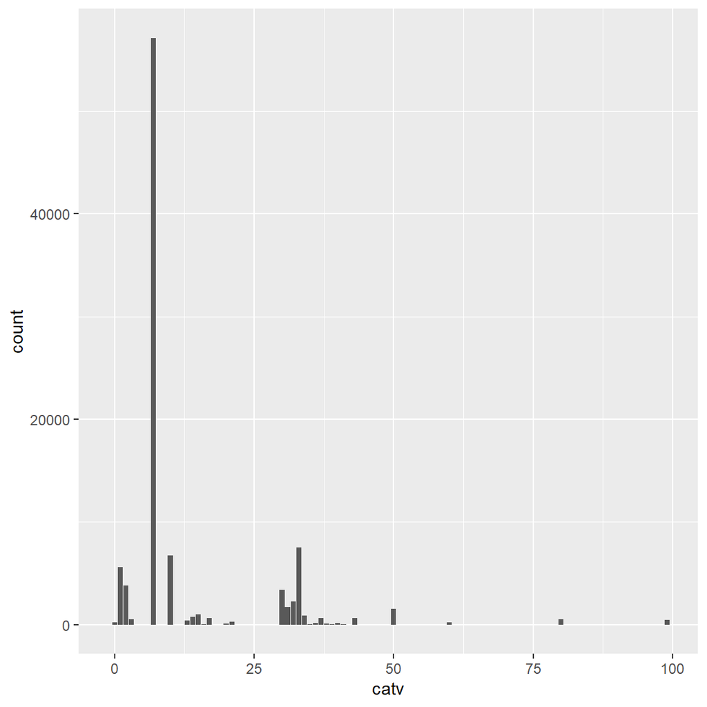

```r
var_name <- 'catv'
original_vehicules %>% get_countplot(var_name)
```

### Featuring

#### Missing

```r
vehicules <- vehicules %>% mutate_all(~ifelse(. == 'N/A', NA, .))
vehicules <- vehicules %>% mutate_all(~ifelse(. == '-1', NA, .))
vehicules <- vehicules %>% mutate_all(~ifelse(. == -1, NA, .))
vehicules %>% get_missing() %>% render_df()
```

|  | variable | dtype | count | unique | missing | missing_prop |
| --- | --- | --- | --- | --- | --- | --- |
| Num_Acc | Num_Acc | numeric | 97315 | 56518 | 0 | 0.00 |
| id_vehicule | id_vehicule | character | 97315 | 97315 | 0 | 0.00 |
| num_veh | num_veh | character | 97315 | 53 | 0 | 0.00 |
| senc | senc | integer | 97315 | 4 | 407 | 0.42 |
| catv | catv | integer | 97315 | 31 | 4 | 0.00 |
| obs | obs | integer | 97315 | 18 | 24 | 0.02 |
| obsm | obsm | integer | 97315 | 7 | 38 | 0.04 |
| choc | choc | integer | 97315 | 10 | 44 | 0.05 |
| manv | manv | integer | 97315 | 27 | 20 | 0.02 |
| motor | motor | integer | 97315 | 7 | 167 | 0.17 |
| occutc | occutc | integer | 97315 | 18 | 96571 | 99.24 |

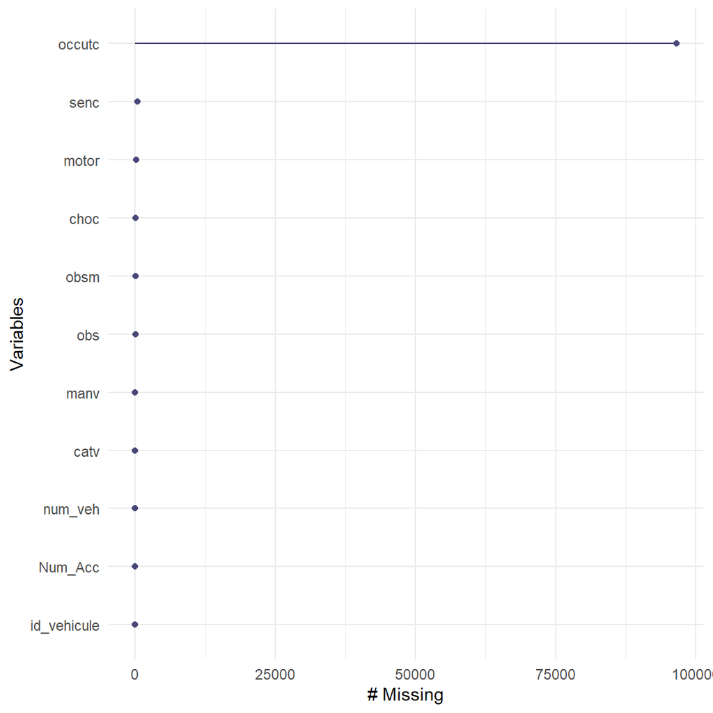

```r
vehicules %>% gg_miss_var()
```

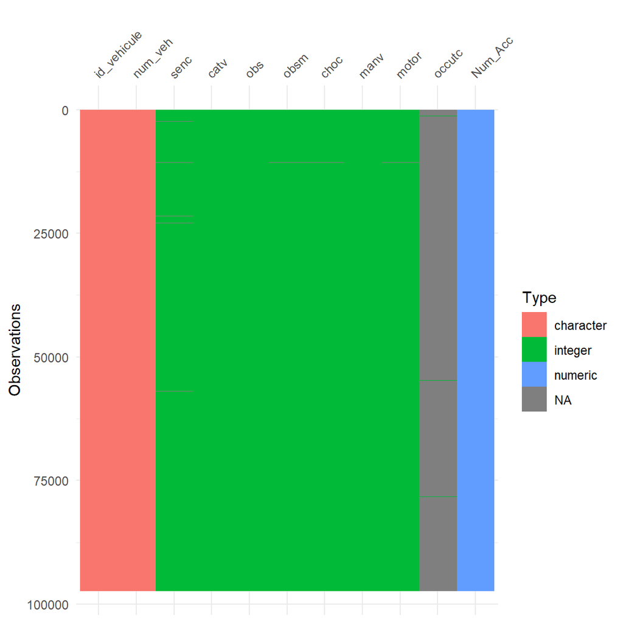

```r
vehicules %>% vis_dat(warn_large_data=FALSE)
```

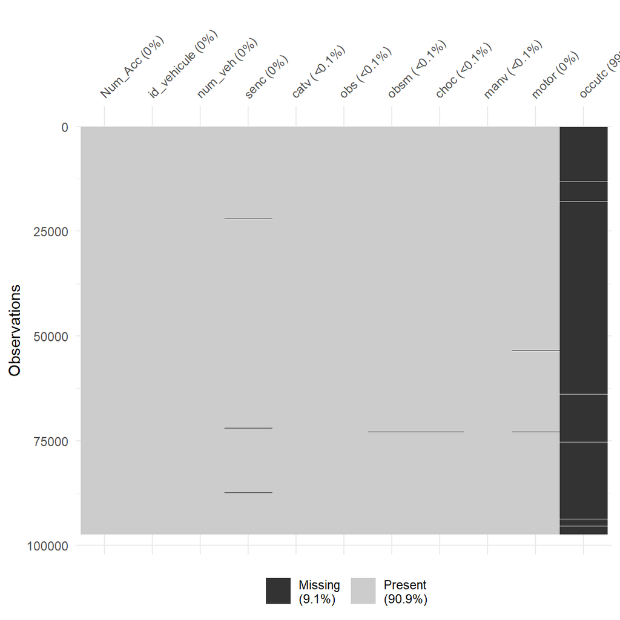

```r
vehicules %>% vis_miss(warn_large_data=FALSE)
```

#### Engineering

```r
vehicules <- vehicules %>%
  mutate(catv,
    catveh = if_else(catv %in% c(1, 2, 3, 30, 31, 32, 33, 34, 35, 36, 41, 42, 43, 50, 60, 80),
      "Deux-roues",
      if_else(catv %in% c(7, 10), "VL/VU",
        if_else(catv %in% c(13, 14, 15, 37, 38), "PL", "Autres")
      )
    )
  ) %>%
  mutate(obs, obstacle = if_else(obs != 0, "non", "oui")) %>%
  mutate(choc, choc_gr = if_else(choc == 0, "aucun",
    if_else(choc %in% c(1, 2, 3), "avant",
      if_else(choc %in% c(4, 5, 6), "arriere",
        if_else(choc %in% c(7, 8), "coté", "multiples")
      )
    )
  ))
```

#### Setting

```r
strings <- c(
  'Num_Acc', # note that a single accident can involve several vehicles
  'id_vehicule'
)
factors <- c(
  'catveh',
  'obstacle',
  'choc_gr'
)
numericals <- c(
)
to_drop <- c(
  'num_veh', # irrelevant
  'occutc', # 99% missing
  'senc', #irrelevant
  'catv', #keep catveh instead
  'motor', # unknown or NA
  'obs', #keep obstacle
  'senc',
  'choc',
  'manv',
  'obsm'
)

vehicules <- vehicules %>% set_data(numericals, factors, strings)
vehicules <- vehicules %>% del_vars(to_drop)
```

### Summary

#### head

```r
vehicules %>% head() %>% render_df()
```

| Num_Acc | id_vehicule | catveh | obstacle | choc_gr |
| --- | --- | --- | --- | --- |
| 202100000001 | 201 764 | Deux-roues | oui | avant |
| 202100000001 | 201 765 | VL/VU | oui | avant |
| 202100000002 | 201 762 | VL/VU | non | avant |
| 202100000002 | 201 763 | VL/VU | oui | avant |
| 202100000003 | 201 761 | VL/VU | oui | avant |
| 202100000004 | 201 758 | VL/VU | oui | avant |

#### str

```r
vehicules %>% str()
```

```
## 'data.frame':    97315 obs. of  5 variables:
##  $ Num_Acc    : chr  "202100000001" "202100000001" "202100000002" "202100000002" ...
##  $ id_vehicule: chr  "201 764" "201 765" "201 762" "201 763" ...
##  $ catveh     : Factor w/ 4 levels "Autres","Deux-roues",..: 2 4 4 4 4 4 2 4 4 2 ...
##  $ obstacle   : Factor w/ 2 levels "non","oui": 2 2 1 2 2 2 2 2 2 2 ...
##  $ choc_gr    : Factor w/ 5 levels "arriere","aucun",..: 3 3 3 3 3 3 4 1 3 1 ...
```

#### summary

```r
vehicules %>% summary() %>% render_df()
```

|  | Num_Acc | id_vehicule | catveh | obstacle | choc_gr |
| --- | --- | --- | --- | --- | --- |
|  | Length:97315 | Length:97315 | Autres : 1872 | non :13735 | arriere :15928 |
|  | Class :character | Class :character | Deux-roues:28762 | oui :83556 | aucun : 6288 |
|  | Mode :character | Mode :character | PL : 2835 | NA’s: 24 | avant :61228 |
|  | NA | NA | VL/VU :63846 | NA | coté :12513 |
|  | NA | NA | NA | NA | multiples: 1314 |
|  | NA | NA | NA | NA | NA’s : 44 |

#### missing

```r
vehicules %>% get_missing() %>% render_df()
```

|  | variable | dtype | count | unique | missing | missing_prop |
| --- | --- | --- | --- | --- | --- | --- |
| Num_Acc | Num_Acc | character | 97315 | 56518 | 0 | 0.00 |
| id_vehicule | id_vehicule | character | 97315 | 97315 | 0 | 0.00 |
| catveh | catveh | factor | 97315 | 4 | 0 | 0.00 |
| obstacle | obstacle | factor | 97315 | 2 | 24 | 0.02 |
| choc_gr | choc_gr | factor | 97315 | 5 | 44 | 0.05 |

### Saving

```r
vehicules_dtypes <- vehicules %>% get_dtypes()

vehicules %>% write.csv2('preprocessed_vehicules.csv', row.names=FALSE)
vehicules_dtypes %>% write.csv2('preprocessed_vehicules_dtypes.csv', row.names=FALSE)
```

## Usagers

### Acquisition

```r
original_usagers <- read.csv2(
  'usagers-2021.csv',
  header=TRUE,
  sep=";"
)
usagers <- original_usagers
```

#### head

```r
original_usagers %>% head() %>% render_df()
```

| Num_Acc | id_vehicule | num_veh | place | catu | grav | sexe | an_nais | trajet | secu1 | secu2 | secu3 | locp | actp | etatp |
| --- | --- | --- | --- | --- | --- | --- | --- | --- | --- | --- | --- | --- | --- | --- |
| 2.021e+11 | 201 764 | B01 | 1 | 1 | 3 | 1 | 2000 | 1 | 0 | 9 | -1 | 0 | 0 | -1 |
| 2.021e+11 | 201 765 | A01 | 1 | 1 | 1 | 1 | 1978 | 1 | 1 | -1 | -1 | 0 | 0 | -1 |
| 2.021e+11 | 201 762 | A01 | 1 | 1 | 4 | 1 | 1983 | 0 | 1 | -1 | -1 | 0 | 0 | -1 |
| 2.021e+11 | 201 763 | B01 | 1 | 1 | 3 | 1 | 1993 | 0 | 1 | -1 | -1 | 0 | 0 | -1 |
| 2.021e+11 | 201 761 | A01 | 1 | 1 | 1 | 1 | 1995 | 1 | 1 | 0 | -1 | 0 | 0 | -1 |
| 2.021e+11 | 201 761 | A01 | 10 | 3 | 3 | 2 | 1959 | 4 | 0 | -1 | -1 | 3 | 3 | 1 |

#### str

```r
original_usagers %>% str()
```

```
## 'data.frame':    129153 obs. of  15 variables:
##  $ Num_Acc    : num  2.02e+11 2.02e+11 2.02e+11 2.02e+11 2.02e+11 ...
##  $ id_vehicule: chr  "201 764" "201 765" "201 762" "201 763" ...
##  $ num_veh    : chr  "B01" "A01" "A01" "B01" ...
##  $ place      : int  1 1 1 1 1 10 1 1 1 1 ...
##  $ catu       : int  1 1 1 1 1 3 1 1 1 1 ...
##  $ grav       : int  3 1 4 3 1 3 1 2 4 -1 ...
##  $ sexe       : int  1 1 1 1 1 2 1 2 2 -1 ...
##  $ an_nais    : int  2000 1978 1983 1993 1995 1959 2000 2014 1997 NA ...
##  $ trajet     : int  1 1 0 0 1 4 -1 5 1 -1 ...
##  $ secu1      : int  0 1 1 1 1 0 -1 0 1 8 ...
##  $ secu2      : int  9 -1 -1 -1 0 -1 0 -1 -1 -1 ...
##  $ secu3      : int  -1 -1 -1 -1 -1 -1 -1 -1 -1 -1 ...
##  $ locp       : int  0 0 0 0 0 3 -1 -1 -1 -1 ...
##  $ actp       : chr  "0" "0" "0" "0" ...
##  $ etatp      : int  -1 -1 -1 -1 -1 1 -1 -1 -1 -1 ...
```

#### summary

```r
original_usagers %>% summary() %>% render_df()
```

|  | Num_Acc | id_vehicule | num_veh | place | catu | grav | sexe | an_nais | trajet | secu1 | secu2 | secu3 | locp | actp | etatp |
| --- | --- | --- | --- | --- | --- | --- | --- | --- | --- | --- | --- | --- | --- | --- | --- |
|  | Min. :2.021e+11 | Length:129153 | Length:129153 | Min. :-1.000 | Min. :1.00 | Min. :-1.00 | Min. :-1.000 | Min. :1912 | Min. :-1.000 | Min. :-1.000 | Min. :-1.0000 | Min. :-1.0000 | Min. :-1.0000 | Length:129153 | Min. :-1.0000 |
|  | 1st Qu.:2.021e+11 | Class :character | Class :character | 1st Qu.: 1.000 | 1st Qu.:1.00 | 1st Qu.: 1.00 | 1st Qu.: 1.000 | 1st Qu.:1970 | 1st Qu.: 0.000 | 1st Qu.: 1.000 | 1st Qu.:-1.0000 | 1st Qu.:-1.0000 | 1st Qu.:-1.0000 | Class :character | 1st Qu.:-1.0000 |
|  | Median :2.021e+11 | Mode :character | Mode :character | Median : 1.000 | Median :1.00 | Median : 3.00 | Median : 1.000 | Median :1987 | Median : 4.000 | Median : 1.000 | Median : 0.0000 | Median :-1.0000 | Median :-1.0000 | Mode :character | Median :-1.0000 |
|  | Mean :2.021e+11 | NA | NA | Mean : 2.035 | Mean :1.32 | Mean : 2.52 | Mean : 1.261 | Mean :1983 | Mean : 3.162 | Mean : 1.823 | Mean : 0.9602 | Mean :-0.9174 | Mean :-0.2683 | NA | Mean :-0.8349 |
|  | 3rd Qu.:2.021e+11 | NA | NA | 3rd Qu.: 1.000 | 3rd Qu.:1.00 | 3rd Qu.: 4.00 | 3rd Qu.: 2.000 | 3rd Qu.:1998 | 3rd Qu.: 5.000 | 3rd Qu.: 2.000 | 3rd Qu.: 0.0000 | 3rd Qu.:-1.0000 | 3rd Qu.: 0.0000 | NA | 3rd Qu.:-1.0000 |
|  | Max. :2.021e+11 | NA | NA | Max. :10.000 | Max. :3.00 | Max. : 4.00 | Max. : 2.000 | Max. :2021 | Max. : 9.000 | Max. : 9.000 | Max. : 9.0000 | Max. : 9.0000 | Max. : 9.0000 | NA | Max. : 3.0000 |
|  | NA | NA | NA | NA | NA | NA | NA | NA’s :3067 | NA | NA | NA | NA | NA | NA | NA |

#### missing

```r
original_usagers %>% get_missing() %>% render_df()
```

|  | variable | dtype | count | unique | missing | missing_prop |
| --- | --- | --- | --- | --- | --- | --- |
| Num_Acc | Num_Acc | numeric | 129153 | 56518 | 0 | 0.00 |
| id_vehicule | id_vehicule | character | 129153 | 97309 | 0 | 0.00 |
| num_veh | num_veh | character | 129153 | 53 | 0 | 0.00 |
| place | place | integer | 129153 | 11 | 0 | 0.00 |
| catu | catu | integer | 129153 | 3 | 0 | 0.00 |
| grav | grav | integer | 129153 | 5 | 0 | 0.00 |
| sexe | sexe | integer | 129153 | 3 | 0 | 0.00 |
| an_nais | an_nais | integer | 129153 | 104 | 3067 | 2.37 |
| trajet | trajet | integer | 129153 | 8 | 0 | 0.00 |
| secu1 | secu1 | integer | 129153 | 11 | 0 | 0.00 |
| secu2 | secu2 | integer | 129153 | 11 | 0 | 0.00 |
| secu3 | secu3 | integer | 129153 | 9 | 0 | 0.00 |
| locp | locp | integer | 129153 | 11 | 0 | 0.00 |
| actp | actp | character | 129153 | 13 | 0 | 0.00 |
| etatp | etatp | integer | 129153 | 4 | 0 | 0.00 |

#### visual

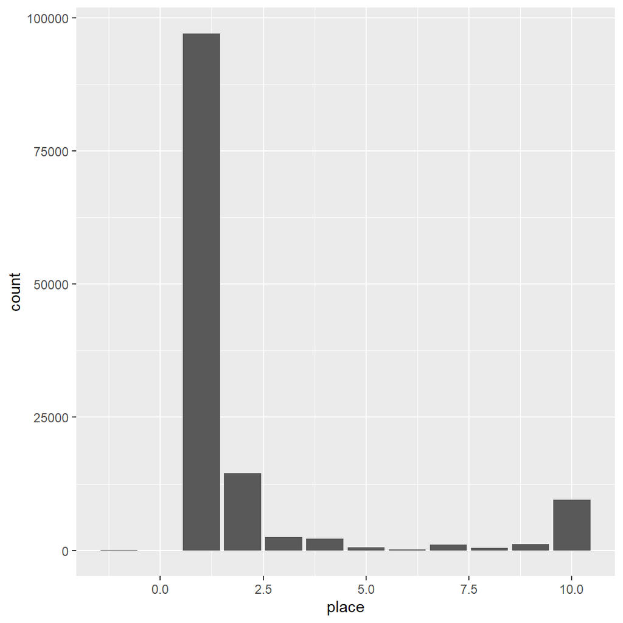

```r
var_name <- 'place'
original_usagers %>% get_countplot(var_name)
```

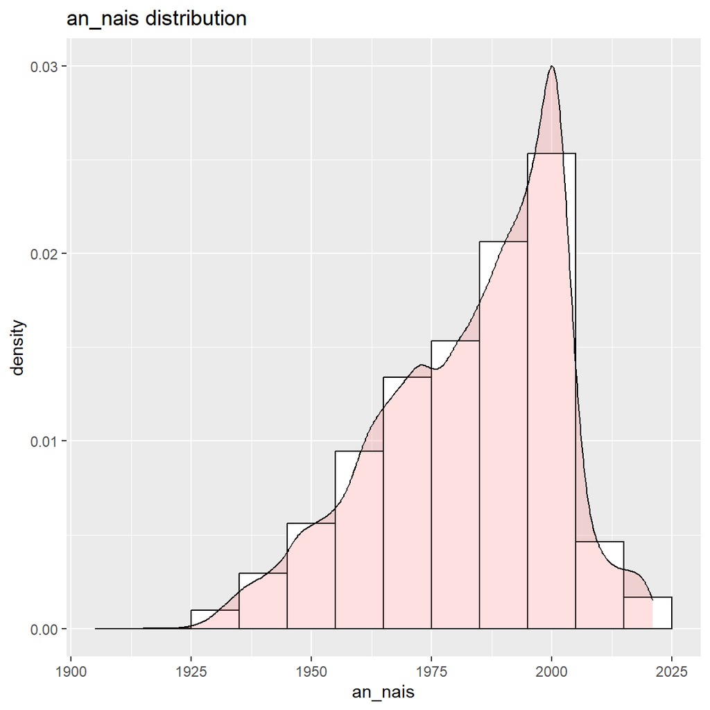

```r
original_usagers %>% get_hist_and_density('an_nais')
```

### Featuring

#### Missing

```r
usagers <- usagers %>% mutate_all(~ifelse(. == 'N/A', NA, .))
usagers <- usagers %>% mutate_all(~ifelse(. == '-1', NA, .))
usagers <- usagers %>% mutate_all(~ifelse(. == -1, NA, .))
usagers %>% get_missing() %>% render_df()
```

|  | variable | dtype | count | unique | missing | missing_prop |
| --- | --- | --- | --- | --- | --- | --- |
| Num_Acc | Num_Acc | numeric | 129153 | 56518 | 0 | 0.00 |
| id_vehicule | id_vehicule | character | 129153 | 97309 | 0 | 0.00 |
| num_veh | num_veh | character | 129153 | 53 | 0 | 0.00 |
| place | place | integer | 129153 | 10 | 17 | 0.01 |
| catu | catu | integer | 129153 | 3 | 0 | 0.00 |
| grav | grav | integer | 129153 | 4 | 60 | 0.05 |
| sexe | sexe | integer | 129153 | 2 | 3062 | 2.37 |
| an_nais | an_nais | integer | 129153 | 104 | 3067 | 2.37 |
| trajet | trajet | integer | 129153 | 7 | 3270 | 2.53 |
| secu1 | secu1 | integer | 129153 | 10 | 2791 | 2.16 |
| secu2 | secu2 | integer | 129153 | 10 | 56010 | 43.37 |
| secu3 | secu3 | integer | 129153 | 8 | 127797 | 98.95 |
| locp | locp | integer | 129153 | 10 | 64603 | 50.02 |
| actp | actp | character | 129153 | 13 | 0 | 0.00 |
| etatp | etatp | integer | 129153 | 3 | 119849 | 92.80 |

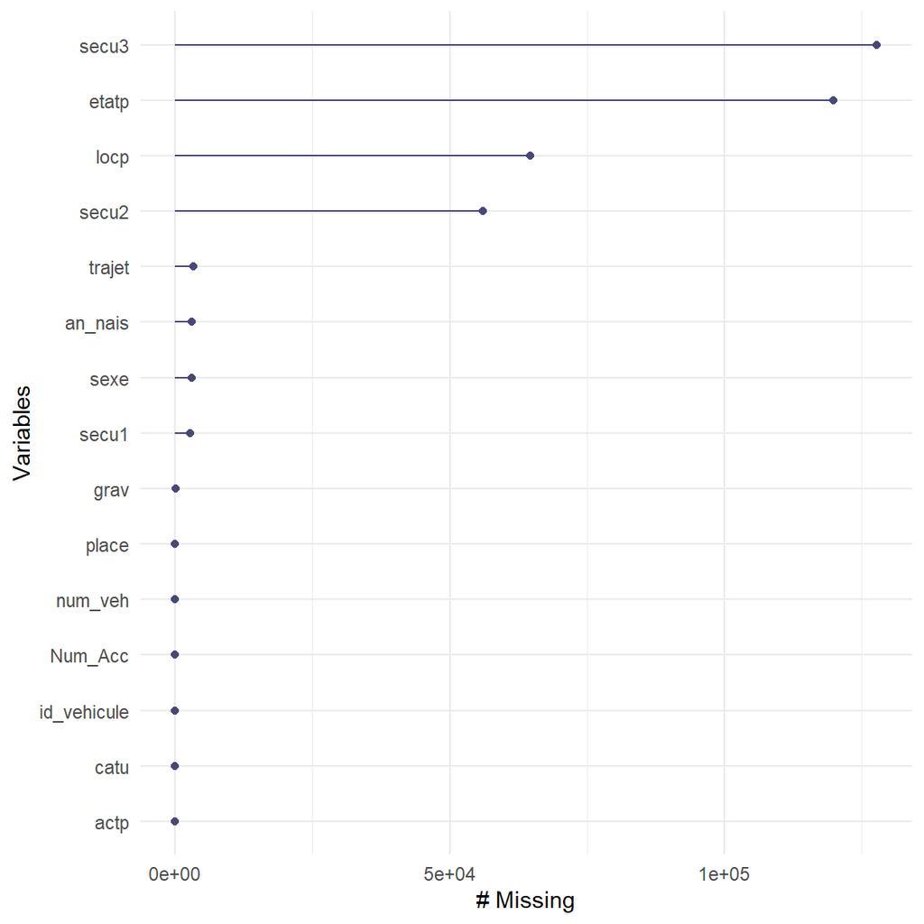

```r
usagers %>% gg_miss_var()
```

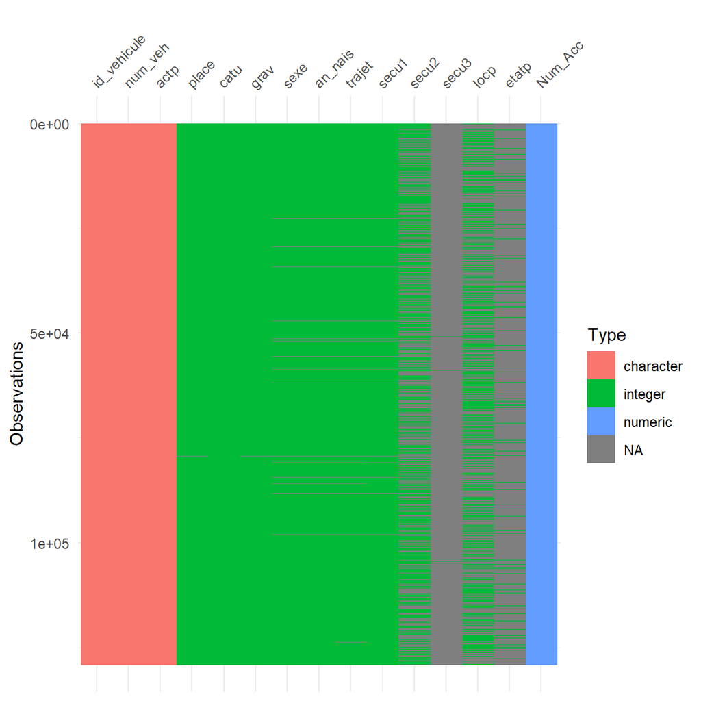

```r
usagers %>% vis_dat(warn_large_data=FALSE)
```

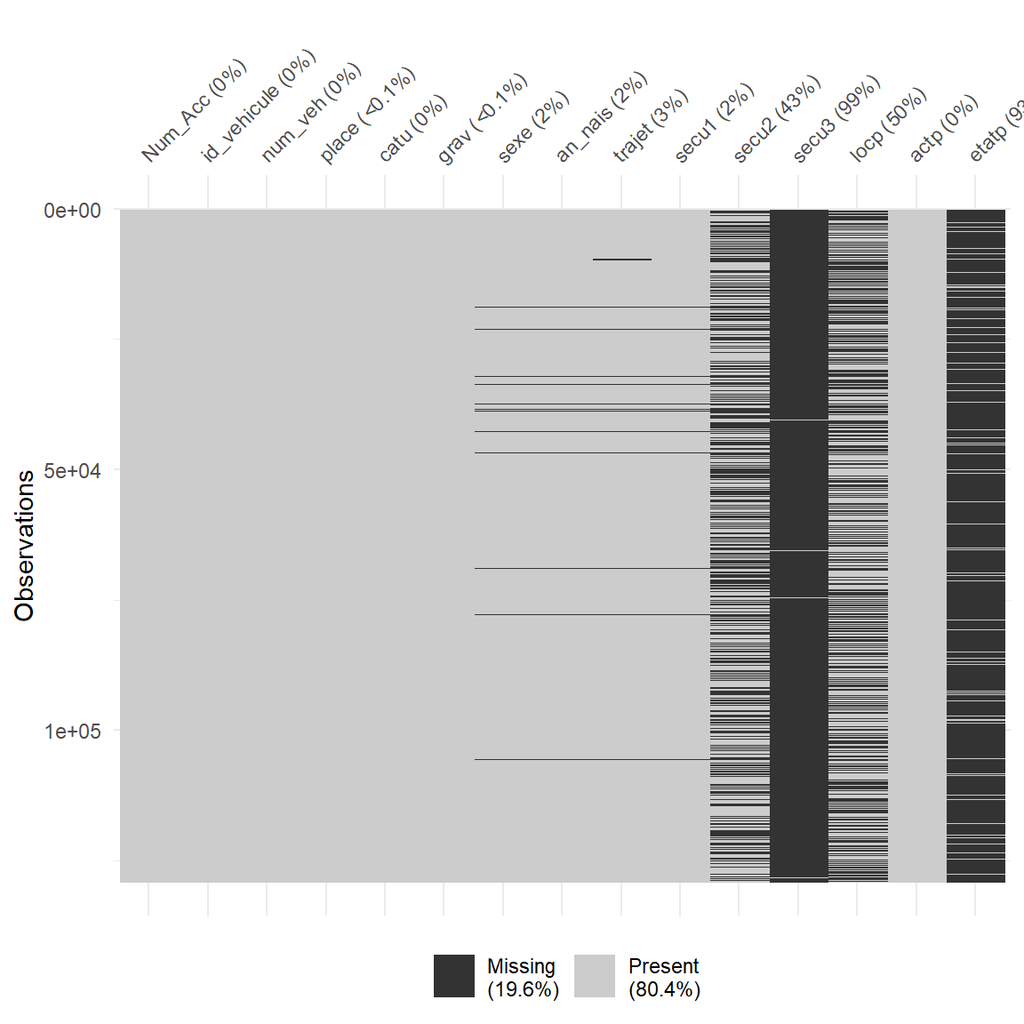

```r
usagers %>% vis_miss(warn_large_data=FALSE)
```

#### Engineering

```r
usagers <- usagers %>% mutate(secu1, secu = if_else(secu1 == 0, 'non', 'oui')) %>%
                       mutate(secu2, secu_2 = if_else(secu2 == 0, 'non', 'oui'))

usagers <- usagers %>% filter(grav!=-1)
usagers$id_usager <- as.character(1:nrow(usagers)) # add an index
```

#### Setting

```r
strings <- c(
  'Num_Acc',
  'id_vehicule',
  'id_usager'
)
factors <- c(
  'place', #faire conducteur vs passager
  'catu',
  'grav',
  'sexe',
  'secu',
  'secu_2'
)
numericals <- c(
  'an_nais'
)
to_drop <- c(
  'secu3', # too many NA, non NAs are note relevant (usagers$secu3 %>% table)
  'etatp',
  'actp',
  'locp',
  'num_veh',
  'secu1',
  'secu2',
  'trajet'
)

usagers <- usagers %>% set_data(numericals, factors, strings)
usagers <- usagers %>% del_vars(to_drop)
```

### Summary

#### head

```r
usagers %>% head() %>% render_df()
```

| Num_Acc | id_vehicule | place | catu | grav | sexe | an_nais | secu | secu_2 | id_usager |
| --- | --- | --- | --- | --- | --- | --- | --- | --- | --- |
| 202100000001 | 201 764 | 1 | 1 | 3 | 1 | 2000 | non | oui | 1 |
| 202100000001 | 201 765 | 1 | 1 | 1 | 1 | 1978 | oui | NA | 2 |
| 202100000002 | 201 762 | 1 | 1 | 4 | 1 | 1983 | oui | NA | 3 |
| 202100000002 | 201 763 | 1 | 1 | 3 | 1 | 1993 | oui | NA | 4 |
| 202100000003 | 201 761 | 1 | 1 | 1 | 1 | 1995 | oui | non | 5 |
| 202100000003 | 201 761 | 10 | 3 | 3 | 2 | 1959 | non | NA | 6 |

#### str

```r
usagers %>% str()
```

```
## 'data.frame':    129093 obs. of  10 variables:
##  $ Num_Acc    : chr  "202100000001" "202100000001" "202100000002" "202100000002" ...
##  $ id_vehicule: chr  "201 764" "201 765" "201 762" "201 763" ...
##  $ place      : Factor w/ 10 levels "1","2","3","4",..: 1 1 1 1 1 10 1 1 1 1 ...
##  $ catu       : Factor w/ 3 levels "1","2","3": 1 1 1 1 1 3 1 1 1 1 ...
##  $ grav       : Factor w/ 4 levels "1","2","3","4": 3 1 4 3 1 3 1 2 4 4 ...
##  $ sexe       : Factor w/ 2 levels "1","2": 1 1 1 1 1 2 1 2 2 1 ...
##  $ an_nais    : int  2000 1978 1983 1993 1995 1959 2000 2014 1997 2009 ...
##  $ secu       : Factor w/ 2 levels "non","oui": 1 2 2 2 2 1 NA 1 2 1 ...
##  $ secu_2     : Factor w/ 2 levels "non","oui": 2 NA NA NA 1 NA 1 NA NA NA ...
##  $ id_usager  : chr  "1" "2" "3" "4" ...
```

#### summary

```r
usagers %>% summary() %>% render_df()
```

|  | Num_Acc | id_vehicule | place | catu | grav | sexe | an_nais | secu | secu_2 | id_usager |
| --- | --- | --- | --- | --- | --- | --- | --- | --- | --- | --- |
|  | Length:129093 | Length:129093 | 1 :96985 | 1:97216 | 1:55108 | 1 :86196 | Min. :1912 | non : 11831 | non :46086 | Length:129093 |
|  | Class :character | Class :character | 2 :14452 | 2:22403 | 2: 3219 | 2 :39895 | 1st Qu.:1970 | oui :114527 | oui :27057 | Class :character |
|  | Mode :character | Mode :character | 10 : 9474 | 3: 9474 | 3:19085 | NA’s: 3002 | Median :1987 | NA’s: 2735 | NA’s:55950 | Mode :character |
|  | NA | NA | 3 : 2474 | NA | 4:51681 | NA | Mean :1983 | NA | NA | NA |
|  | NA | NA | 4 : 2228 | NA | NA | NA | 3rd Qu.:1998 | NA | NA | NA |
|  | NA | NA | 9 : 1187 | NA | NA | NA | Max. :2021 | NA | NA | NA |
|  | NA | NA | (Other): 2293 | NA | NA | NA | NA’s :3007 | NA | NA | NA |

#### missing

```r
usagers %>% get_missing() %>% render_df()
```

|  | variable | dtype | count | unique | missing | missing_prop |
| --- | --- | --- | --- | --- | --- | --- |
| Num_Acc | Num_Acc | character | 129093 | 56518 | 0 | 0.00 |
| id_vehicule | id_vehicule | character | 129093 | 97288 | 0 | 0.00 |
| place | place | factor | 129093 | 10 | 0 | 0.00 |
| catu | catu | factor | 129093 | 3 | 0 | 0.00 |
| grav | grav | factor | 129093 | 4 | 0 | 0.00 |
| sexe | sexe | factor | 129093 | 2 | 3002 | 2.33 |
| an_nais | an_nais | integer | 129093 | 104 | 3007 | 2.33 |
| secu | secu | factor | 129093 | 2 | 2735 | 2.12 |
| secu_2 | secu_2 | factor | 129093 | 2 | 55950 | 43.34 |
| id_usager | id_usager | character | 129093 | 129093 | 0 | 0.00 |

#### visual

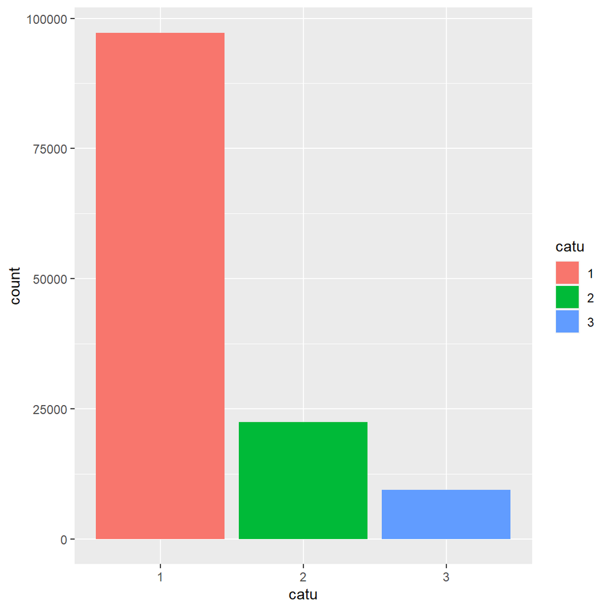

```r
var_name <- 'catu'

usagers %>% get_countplot(var_name)
```

### Saving

```r
usagers_dtypes <- usagers %>% get_dtypes()

usagers %>% write.csv2('preprocessed_usagers.csv', row.names=FALSE)
usagers_dtypes %>% write.csv2('preprocessed_usagers_dtypes.csv', row.names=FALSE)
```

## Final dataset

### Remarque

**Acquisition alternative**

Depuis le début nous avons pris soin de sauvegarder au fur et à mesure les données modifiées pour avoir des checkpoints dans notre projet. Nous pouvons donc choisir de les recharger depuis les fichiers .csv correspondants.

Nous utilisons ici les données en cache.

```r
# Usagers
usagers_dtypes <- read.csv2(
  'preprocessed_usagers_dtypes.csv',
  header=TRUE,
  sep=';'
)
original_usagers <- read.csv2(
  'preprocessed_usagers.csv',
  header=TRUE,
  sep=';',
  colClasses=set_dtypes_df(usagers_dtypes)
)

# Caractéristiques
caract_dtypes <- read.csv2(
  'preprocessed_caract_dtypes.csv',
  header=TRUE,
  sep=';'
)
original_caract <- read.csv2(
  'preprocessed_caract.csv',
  header=TRUE,
  sep=';',
  colClasses=set_dtypes_df(caract_dtypes)
)

# Lieux
lieux_dtypes <- read.csv2(
  'preprocessed_lieux_dtypes.csv',
  header=TRUE,
  sep=';'
)
original_lieux <- read.csv2(
  'preprocessed_lieux.csv',
  header=TRUE,
  sep=';',
  colClasses=set_dtypes_df(lieux_dtypes)
)

# Véhicules
vehicules_dtypes <- read.csv2(
  'preprocessed_vehicules_dtypes.csv',
  header=TRUE,
  sep=';'
)
original_vehicules <- read.csv2(
  'preprocessed_vehicules.csv',
  header=TRUE,
  sep=';',
  colClasses=set_dtypes_df(vehicules_dtypes)
)

usagers <- original_usagers
caract <- original_caract
lieux <- original_lieux
vehicules <- original_vehicules
```

### Acquisition

**From previously ran dataframes**

```r
data <- usagers %>%
  left_join(vehicules, by=c('Num_Acc','id_vehicule')) %>%
  left_join(caract, by='Num_Acc') %>%
  left_join(lieux, by='Num_Acc')

data %>% head() %>% render_df()
```

| Num_Acc | id_vehicule | place | catu | grav | sexe | an_nais | secu | secu_2 | id_usager | catveh | obstacle | choc_gr | agg | lat | long | plage_hh | saison | inter | meteo | collision | eclairage | circ | nbv | vma | surf_gr | prof_gr | plan_gr | infrastructure |
| --- | --- | --- | --- | --- | --- | --- | --- | --- | --- | --- | --- | --- | --- | --- | --- | --- | --- | --- | --- | --- | --- | --- | --- | --- | --- | --- | --- | --- |
| 202100000001 | 201 764 | 1 | 1 | 3 | 1 | 2000 | non | oui | 1 | Deux-roues | oui | avant | 1 | 44 | 4 | matin | automne | Hors intersection | normale | non | éclairé | 2 | 2 | 80 | normale | plat | rectiligne | non |
| 202100000001 | 201 765 | 1 | 1 | 1 | 1 | 1978 | oui | NA | 2 | VL/VU | oui | avant | 1 | 44 | 4 | matin | automne | Hors intersection | normale | non | éclairé | 2 | 2 | 80 | normale | plat | rectiligne | non |
| 202100000002 | 201 762 | 1 | 1 | 4 | 1 | 1983 | oui | NA | 3 | VL/VU | non | avant | 1 | 49 | 4 | apres-midi | été | intersection | normale | non | éclairé | 2 | 2 | 80 | normale | plat | rectiligne | non |
| 202100000002 | 201 763 | 1 | 1 | 3 | 1 | 1993 | oui | NA | 4 | VL/VU | oui | avant | 1 | 49 | 4 | apres-midi | été | intersection | normale | non | éclairé | 2 | 2 | 80 | normale | plat | rectiligne | non |
| 202100000003 | 201 761 | 1 | 1 | 1 | 1 | 1995 | oui | non | 5 | VL/VU | oui | avant | 2 | 46 | 0 | matin | été | Hors intersection | risqué | non | éclairé | 2 | 2 | 50 | normale | plat | rectiligne | non |
| 202100000003 | 201 761 | 10 | 3 | 3 | 2 | 1959 | non | NA | 6 | VL/VU | oui | avant | 2 | 46 | 0 | matin | été | Hors intersection | risqué | non | éclairé | 2 | 2 | 50 | normale | plat | rectiligne | non |

#### head

```r
data %>% head() %>% render_df()
```

| Num_Acc | id_vehicule | place | catu | grav | sexe | an_nais | secu | secu_2 | id_usager | catveh | obstacle | choc_gr | agg | lat | long | plage_hh | saison | inter | meteo | collision | eclairage | circ | nbv | vma | surf_gr | prof_gr | plan_gr | infrastructure |
| --- | --- | --- | --- | --- | --- | --- | --- | --- | --- | --- | --- | --- | --- | --- | --- | --- | --- | --- | --- | --- | --- | --- | --- | --- | --- | --- | --- | --- |
| 202100000001 | 201 764 | 1 | 1 | 3 | 1 | 2000 | non | oui | 1 | Deux-roues | oui | avant | 1 | 44 | 4 | matin | automne | Hors intersection | normale | non | éclairé | 2 | 2 | 80 | normale | plat | rectiligne | non |
| 202100000001 | 201 765 | 1 | 1 | 1 | 1 | 1978 | oui | NA | 2 | VL/VU | oui | avant | 1 | 44 | 4 | matin | automne | Hors intersection | normale | non | éclairé | 2 | 2 | 80 | normale | plat | rectiligne | non |
| 202100000002 | 201 762 | 1 | 1 | 4 | 1 | 1983 | oui | NA | 3 | VL/VU | non | avant | 1 | 49 | 4 | apres-midi | été | intersection | normale | non | éclairé | 2 | 2 | 80 | normale | plat | rectiligne | non |
| 202100000002 | 201 763 | 1 | 1 | 3 | 1 | 1993 | oui | NA | 4 | VL/VU | oui | avant | 1 | 49 | 4 | apres-midi | été | intersection | normale | non | éclairé | 2 | 2 | 80 | normale | plat | rectiligne | non |
| 202100000003 | 201 761 | 1 | 1 | 1 | 1 | 1995 | oui | non | 5 | VL/VU | oui | avant | 2 | 46 | 0 | matin | été | Hors intersection | risqué | non | éclairé | 2 | 2 | 50 | normale | plat | rectiligne | non |
| 202100000003 | 201 761 | 10 | 3 | 3 | 2 | 1959 | non | NA | 6 | VL/VU | oui | avant | 2 | 46 | 0 | matin | été | Hors intersection | risqué | non | éclairé | 2 | 2 | 50 | normale | plat | rectiligne | non |

#### str

```r
data %>% str()
```

```
## 'data.frame':    129093 obs. of  29 variables:
##  $ Num_Acc       : chr  "202100000001" "202100000001" "202100000002" "202100000002" ...
##  $ id_vehicule   : chr  "201 764" "201 765" "201 762" "201 763" ...
##  $ place         : Factor w/ 10 levels "1","2","3","4",..: 1 1 1 1 1 10 1 1 1 1 ...
##  $ catu          : Factor w/ 3 levels "1","2","3": 1 1 1 1 1 3 1 1 1 1 ...
##  $ grav          : Factor w/ 4 levels "1","2","3","4": 3 1 4 3 1 3 1 2 4 4 ...
##  $ sexe          : Factor w/ 2 levels "1","2": 1 1 1 1 1 2 1 2 2 1 ...
##  $ an_nais       : int  2000 1978 1983 1993 1995 1959 2000 2014 1997 2009 ...
##  $ secu          : Factor w/ 2 levels "non","oui": 1 2 2 2 2 1 NA 1 2 1 ...
##  $ secu_2        : Factor w/ 2 levels "non","oui": 2 NA NA NA 1 NA 1 NA NA NA ...
##  $ id_usager     : chr  "1" "2" "3" "4" ...
##  $ catveh        : Factor w/ 4 levels "Autres","Deux-roues",..: 2 4 4 4 4 4 4 2 4 2 ...
##  $ obstacle      : Factor w/ 2 levels "non","oui": 2 2 1 2 2 2 2 2 2 2 ...
##  $ choc_gr       : Factor w/ 5 levels "arriere","aucun",..: 3 3 3 3 3 3 3 4 1 1 ...
##  $ agg           : Factor w/ 2 levels "1","2": 1 1 1 1 2 2 2 2 2 2 ...
##  $ lat           : int  44 44 49 49 46 46 48 48 49 47 ...
##  $ long          : int  4 4 4 4 0 0 2 2 1 7 ...
##  $ plage_hh      : Factor w/ 4 levels "apres-midi","matin",..: 2 2 1 1 2 2 4 4 2 2 ...
##  $ saison        : Factor w/ 4 levels "automne","été",..: 1 1 2 2 2 2 3 3 3 1 ...
##  $ inter         : Factor w/ 2 levels "Hors intersection",..: 1 1 2 2 1 1 2 2 1 2 ...
##  $ meteo         : Factor w/ 2 levels "normale","risqué": 1 1 1 1 2 2 2 2 1 1 ...
##  $ collision     : Factor w/ 2 levels "non","oui": 1 1 1 1 1 1 1 1 1 1 ...
##  $ eclairage     : Factor w/ 2 levels "éclairé","peu éclairé": 1 1 1 1 1 1 1 1 1 1 ...
##  $ circ          : Factor w/ 4 levels "1","2","3","4": 2 2 2 2 2 2 2 2 2 2 ...
##  $ nbv           : int  2 2 2 2 2 2 4 4 2 2 ...
##  $ vma           : int  80 80 80 80 50 50 50 50 50 50 ...
##  $ surf_gr       : Factor w/ 2 levels "normale","risquée": 1 1 1 1 1 1 1 1 1 1 ...
##  $ prof_gr       : Factor w/ 2 levels "pente/cote","plat": 2 2 2 2 2 2 2 2 2 2 ...
##  $ plan_gr       : Factor w/ 2 levels "courbe","rectiligne": 2 2 2 2 2 2 2 2 2 2 ...
##  $ infrastructure: Factor w/ 2 levels "non","oui": 1 1 1 1 1 1 1 1 1 1 ...
```

#### summary

```r
data %>% summary() %>% render_df()
```

|  | Num_Acc | id_vehicule | place | catu | grav | sexe | an_nais | secu | secu_2 | id_usager | catveh | obstacle | choc_gr | agg | lat | long | plage_hh | saison | inter | meteo | collision | eclairage | circ | nbv | vma | surf_gr | prof_gr | plan_gr | infrastructure |
| --- | --- | --- | --- | --- | --- | --- | --- | --- | --- | --- | --- | --- | --- | --- | --- | --- | --- | --- | --- | --- | --- | --- | --- | --- | --- | --- | --- | --- | --- |
|  | Length:129093 | Length:129093 | 1 :96985 | 1:97216 | 1:55108 | 1 :86196 | Min. :1912 | non : 11831 | non :46086 | Length:129093 | Autres : 2299 | non : 20058 | arriere :20917 | 1 :45387 | Min. :41.00 | Min. :-5.000 | apres-midi:54265 | automne :32796 | Hors intersection:76545 | normale:96886 | non :114620 | éclairé :110391 | 1 :23319 | Min. : 0.000 | Min. : 10.00 | normale:104334 | pente/cote: 23931 | courbe : 23247 | non :108355 |
|  | Class :character | Class :character | 2 :14452 | 2:22403 | 2: 3219 | 2 :39895 | 1st Qu.:1970 | oui :114527 | oui :27057 | Class :character | Deux-roues:32967 | oui :109004 | aucun : 7879 | 2 :76655 | 1st Qu.:45.00 | 1st Qu.: 1.000 | matin :37390 | été :34561 | intersection :45497 | risqué :25141 | oui : 7388 | peu éclairé: 11651 | 2 :77665 | 1st Qu.: 2.000 | 1st Qu.: 50.00 | risquée: 24732 | plat :105136 | rectiligne:105815 | oui : 19457 |
|  | Mode :character | Mode :character | 10 : 9474 | 3: 9474 | 3:19085 | NA’s: 3002 | Median :1987 | NA’s: 2735 | NA’s:55950 | Mode :character | PL : 3720 | NA’s: 31 | avant :82491 | NA’s: 7051 | Median :48.00 | Median : 2.000 | nuit :11066 | hiver :23538 | NA’s : 7051 | NA’s : 7066 | NA’s: 7085 | NA’s : 7051 | 3 :20095 | Median : 2.000 | Median : 50.00 | NA’s : 27 | NA’s : 26 | NA’s : 31 | NA’s: 1281 |
|  | NA | NA | 3 : 2474 | NA | 4:51681 | NA | Mean :1983 | NA | NA | NA | VL/VU :90107 | NA | coté :15737 | NA | Mean :46.42 | Mean : 2.389 | soirée :19321 | printemps:31147 | NA | NA | NA | NA | 4 : 886 | Mean : 2.488 | Mean : 61.23 | NA | NA | NA | NA |
|  | NA | NA | 4 : 2228 | NA | NA | NA | 3rd Qu.:1998 | NA | NA | NA | NA | NA | multiples: 2017 | NA | 3rd Qu.:48.00 | 3rd Qu.: 4.000 | NA’s : 7051 | NA’s : 7051 | NA | NA | NA | NA | NA’s: 7128 | 3rd Qu.: 3.000 | 3rd Qu.: 80.00 | NA | NA | NA | NA |
|  | NA | NA | 9 : 1187 | NA | NA | NA | Max. :2021 | NA | NA | NA | NA | NA | NA’s : 52 | NA | Max. :51.00 | Max. : 9.000 | NA | NA | NA | NA | NA | NA | NA | Max. :12.000 | Max. :130.00 | NA | NA | NA | NA |
|  | NA | NA | (Other): 2293 | NA | NA | NA | NA’s :3007 | NA | NA | NA | NA | NA | NA | NA | NA’s :7051 | NA’s :7051 | NA | NA | NA | NA | NA | NA | NA | NA’s :1229 | NA’s :2027 | NA | NA | NA | NA |

#### missing

```r
data %>% get_missing() %>% arrange(desc(missing_prop)) %>% render_df()
```

|  | variable | dtype | count | unique | missing | missing_prop |
| --- | --- | --- | --- | --- | --- | --- |
| secu_2 | secu_2 | factor | 129093 | 2 | 55950 | 43.34 |
| circ | circ | factor | 129093 | 4 | 7128 | 5.52 |
| collision | collision | factor | 129093 | 2 | 7085 | 5.49 |
| meteo | meteo | factor | 129093 | 2 | 7066 | 5.47 |
| agg | agg | factor | 129093 | 2 | 7051 | 5.46 |
| lat | lat | integer | 129093 | 11 | 7051 | 5.46 |
| long | long | integer | 129093 | 15 | 7051 | 5.46 |
| plage_hh | plage_hh | factor | 129093 | 4 | 7051 | 5.46 |
| saison | saison | factor | 129093 | 4 | 7051 | 5.46 |
| inter | inter | factor | 129093 | 2 | 7051 | 5.46 |
| eclairage | eclairage | factor | 129093 | 2 | 7051 | 5.46 |
| sexe | sexe | factor | 129093 | 2 | 3002 | 2.33 |
| an_nais | an_nais | integer | 129093 | 104 | 3007 | 2.33 |
| secu | secu | factor | 129093 | 2 | 2735 | 2.12 |
| vma | vma | integer | 129093 | 18 | 2027 | 1.57 |
| infrastructure | infrastructure | factor | 129093 | 2 | 1281 | 0.99 |
| nbv | nbv | integer | 129093 | 13 | 1229 | 0.95 |
| choc_gr | choc_gr | factor | 129093 | 5 | 52 | 0.04 |
| obstacle | obstacle | factor | 129093 | 2 | 31 | 0.02 |
| surf_gr | surf_gr | factor | 129093 | 2 | 27 | 0.02 |
| prof_gr | prof_gr | factor | 129093 | 2 | 26 | 0.02 |
| plan_gr | plan_gr | factor | 129093 | 2 | 31 | 0.02 |
| Num_Acc | Num_Acc | character | 129093 | 56518 | 0 | 0.00 |
| id_vehicule | id_vehicule | character | 129093 | 97288 | 0 | 0.00 |
| place | place | factor | 129093 | 10 | 0 | 0.00 |
| catu | catu | factor | 129093 | 3 | 0 | 0.00 |
| grav | grav | factor | 129093 | 4 | 0 | 0.00 |
| id_usager | id_usager | character | 129093 | 129093 | 0 | 0.00 |
| catveh | catveh | factor | 129093 | 4 | 0 | 0.00 |

```r
data %>% gg_miss_var()
```

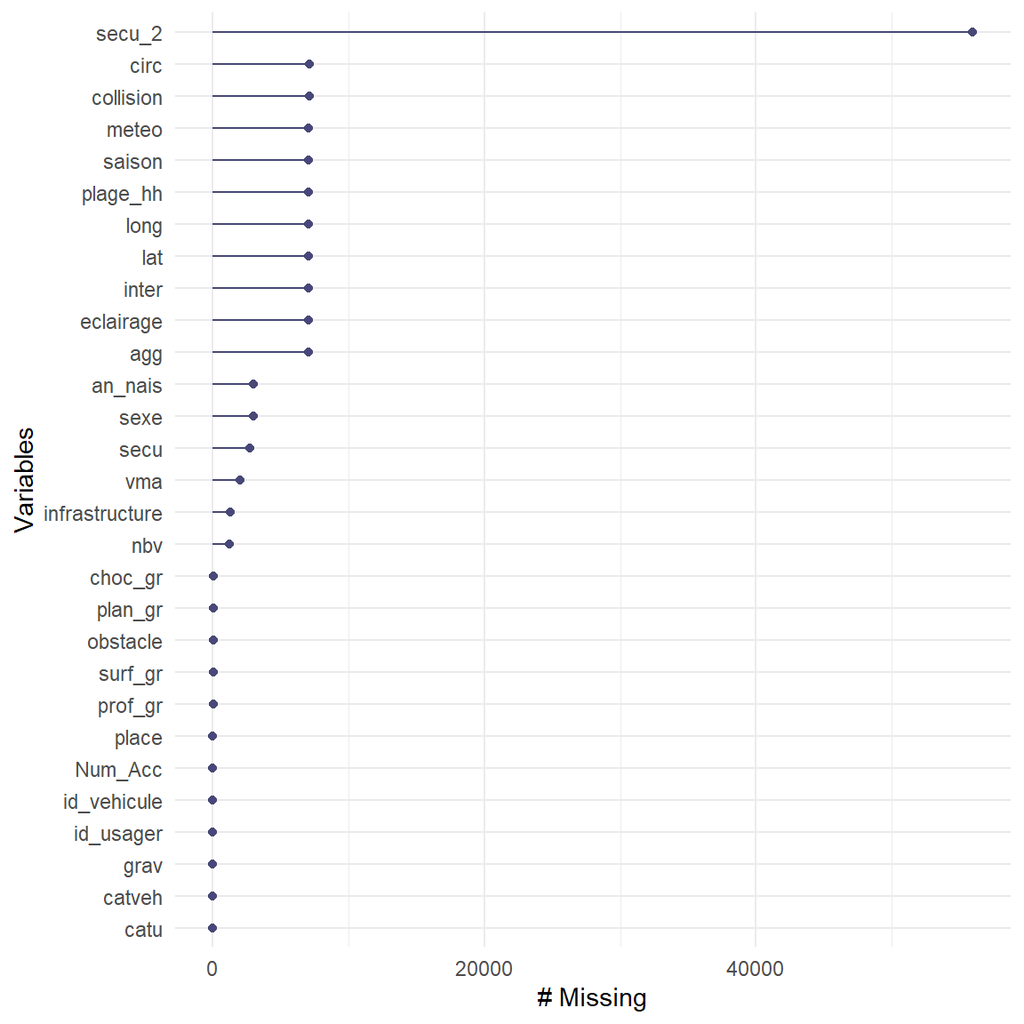

```r
data %>% vis_dat(warn_large_data=FALSE)
```

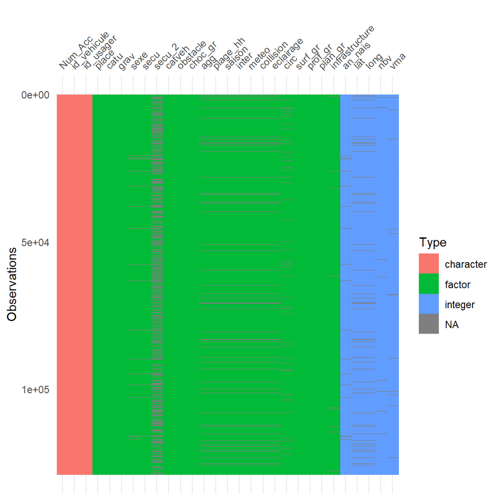

```r
data %>% vis_miss(warn_large_data=FALSE)
```

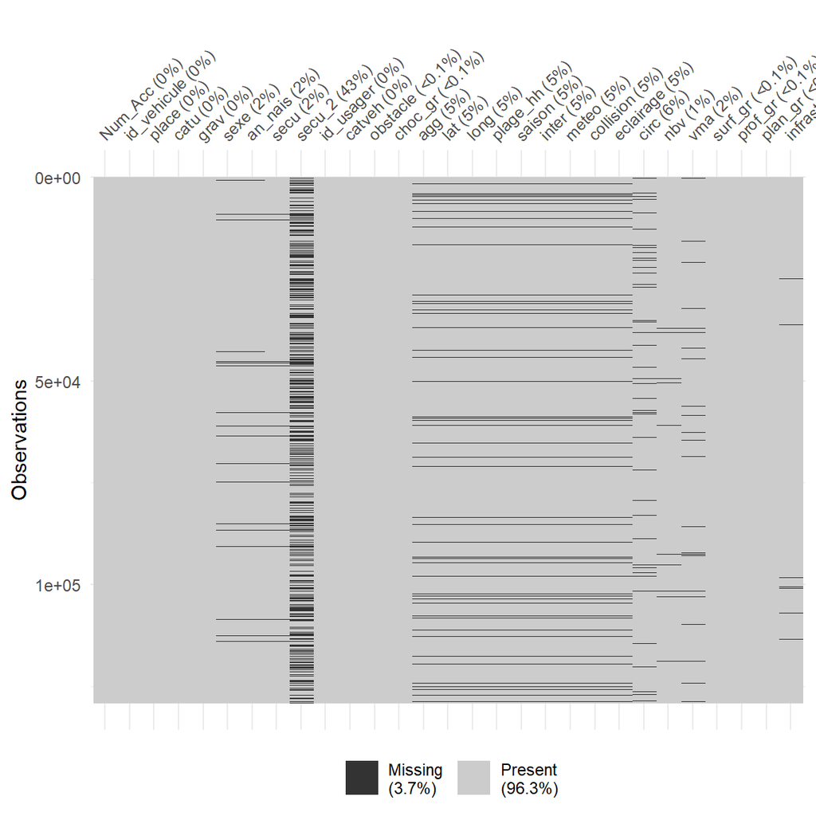

#### visual

```r
target_name <- 'grav'
num_vars <- data %>% select_if(is.integer)
cat_vars <- data %>% select_if(is.factor) %>% select(-target_name)
```

**Target**

```r
data[, target_name] %>% table()
```

```
## .
##     1     2     3     4
## 55108  3219 19085 51681
```

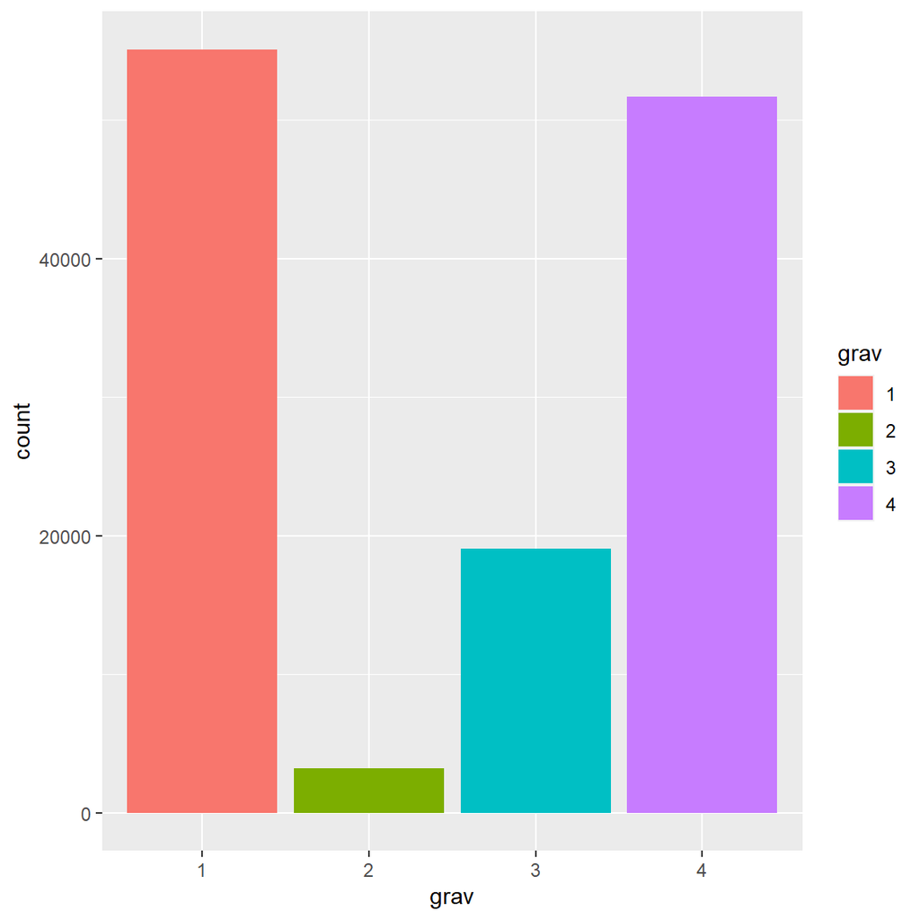

```r
data %>% get_countplot(target_name)
```

**Categorical**

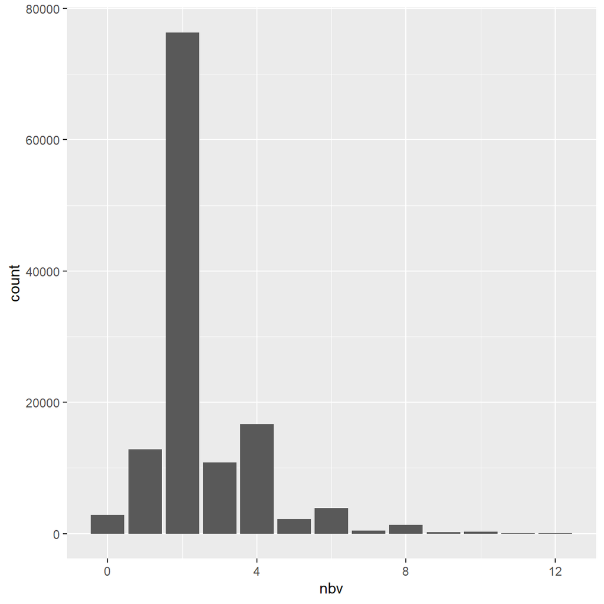

```r
var_name <- 'nbv'

data %>% get_countplot(var_name)
```

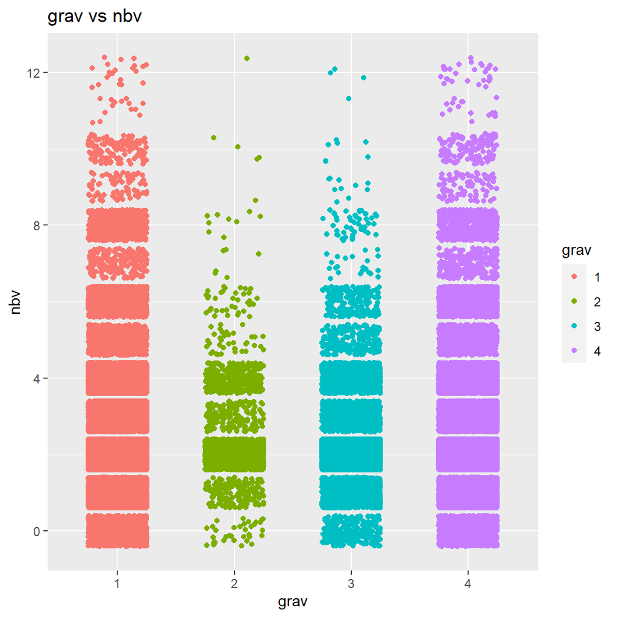

```r
data %>% plot_cat_vs_cat(target_name, var_name)
```

```r
data[, c(target_name, var_name)] %>% table()
```

```
##     nbv
## grav     0     1     2     3     4     5     6     7     8     9    10    11
##    1  1248  5631 31002  4936  7687  1048  1900   204   632    79   136    14
##    2    35   165  2426   159   306    37    37     6     9     1     4     0
##    3   266  1500 14225   938  1479   207   188    22    47    10     7     1
##    4  1262  5504 28674  4784  7207   940  1763   233   618    84   133    17
##     nbv
## grav    12
##    1    21
##    2     1
##    3     3
##    4    28
```

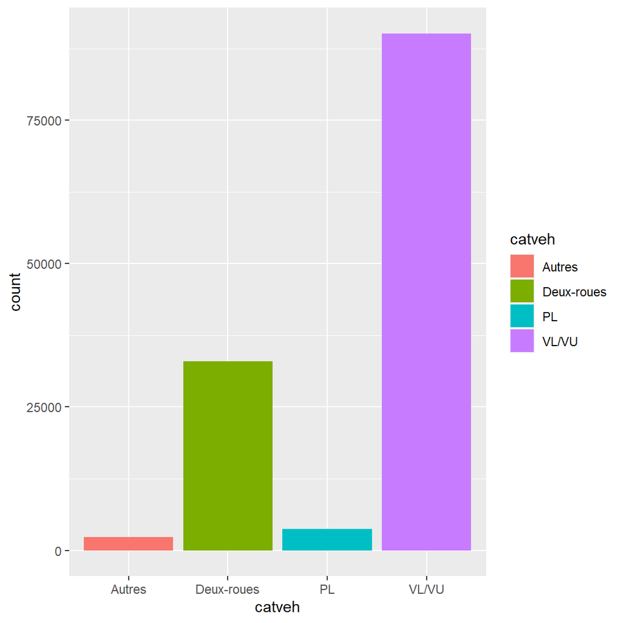

```r
var_name <- 'catveh'

data %>% get_countplot(var_name)
```

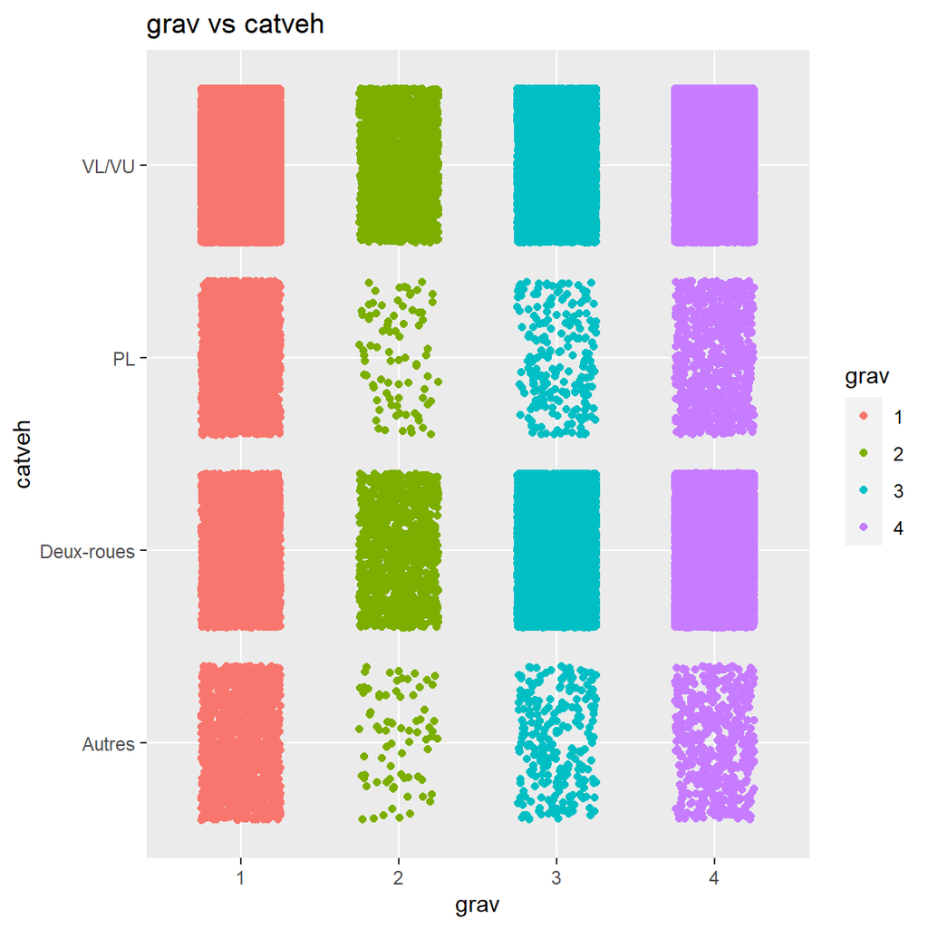

```r
data %>% plot_cat_vs_cat(target_name, var_name)
```

```r
data[, c(target_name, var_name)] %>% table()
```

```
##     catveh
## grav Autres Deux-roues    PL VL/VU
##    1   1426       3481  2617 47584
##    2     76       1098    83  1962
##    3    255       8856   214  9760
##    4    542      19532   806 30801
```

### Saving

```r
data_dtypes <- data %>% get_dtypes()

write.csv2(data, 'preprocessed_data.csv', row.names=FALSE)
write.csv2(data_dtypes, 'preprocessed_data_dtypes.csv', row.names=FALSE)
```

# Processing

### Acquisition

**Acquisition alternative**

```r
data_dtypes <- read.csv2(
  'preprocessed_data_dtypes.csv',
  header=TRUE,
  sep=';'
)
original_data <- read.csv2(
  'preprocessed_data.csv',
  header=TRUE,
  sep=';',
  colClasses=set_dtypes_df(data_dtypes)
)

data <- original_data
```

## Split

```r
train <- data %>% dplyr::sample_frac(0.70)
test  <- dplyr::anti_join(data, train, by = 'id_usager')

train <- subset(train,
                select = !(names(train) %in% c('Num_Acc', 'id_vehicule', 'id_usager')))
test <- subset(test,
               select = !(names(test) %in% c('Num_Acc', 'id_vehicule', 'id_usager')))
```

```r
num_vars <- colnames(select_if(train, is.numeric))
cat_vars <- colnames(select_if(train, is.factor))
cat_vars <- cat_vars[cat_vars != "grav"]
```

## Imputation

```r
train <- train %>%
  mutate_if(is.numeric, ~replace(., is.na(.), median(., na.rm = TRUE))) %>%
  mutate_if(is.factor, ~replace(., is.na(.), most_common(.)))

test <- test %>%
  mutate_if(is.numeric, ~replace(., is.na(.), median(., na.rm = TRUE))) %>%
  mutate_if(is.factor, ~replace(., is.na(.), most_common(.)))
```

## Near Zero-Variance

On vérifie que les variables explicatives sont distribuées dans plusieurs modalités. Dans le cas contraire certains modèles (sauf les modèles à base d’arbres) peuvent être instables.

```r
nzv <- nearZeroVar(train, saveMetrics = TRUE)
nzv %>% arrange(desc(freqRatio)) %>% render_df()
```

|  | freqRatio | percentUnique | zeroVar | nzv |
| --- | --- | --- | --- | --- |
| collision | 16.526183 | 0.0022132 | FALSE | FALSE |
| eclairage | 10.064650 | 0.0022132 | FALSE | FALSE |
| secu | 9.841632 | 0.0022132 | FALSE | FALSE |
| place | 6.682540 | 0.0110662 | FALSE | FALSE |
| infrastructure | 5.643997 | 0.0022132 | FALSE | FALSE |
| obstacle | 5.434879 | 0.0022132 | FALSE | FALSE |
| nbv | 4.602409 | 0.0143861 | FALSE | FALSE |
| plan_gr | 4.577054 | 0.0022132 | FALSE | FALSE |
| prof_gr | 4.380791 | 0.0022132 | FALSE | FALSE |
| catu | 4.314092 | 0.0033199 | FALSE | FALSE |
| surf_gr | 4.184750 | 0.0022132 | FALSE | FALSE |
| meteo | 4.099605 | 0.0022132 | FALSE | FALSE |
| vma | 4.003437 | 0.0199192 | FALSE | FALSE |
| choc_gr | 3.949532 | 0.0055331 | FALSE | FALSE |
| secu_2 | 3.783242 | 0.0022132 | FALSE | FALSE |
| circ | 3.640106 | 0.0044265 | FALSE | FALSE |
| long | 3.467900 | 0.0165993 | FALSE | FALSE |
| catveh | 2.738836 | 0.0044265 | FALSE | FALSE |
| lat | 2.732861 | 0.0121729 | FALSE | FALSE |
| sexe | 2.247269 | 0.0022132 | FALSE | FALSE |
| inter | 1.842292 | 0.0022132 | FALSE | FALSE |
| agg | 1.840327 | 0.0022132 | FALSE | FALSE |
| plage_hh | 1.642214 | 0.0044265 | FALSE | FALSE |
| an_nais | 1.300035 | 0.1117689 | FALSE | FALSE |
| saison | 1.265055 | 0.0044265 | FALSE | FALSE |
| grav | 1.068984 | 0.0044265 | FALSE | FALSE |

> **Pas de variables avec variance presque nulle (contrairement à avant le preprocessing)**

## Correlation

**Variables numériques**

```r
correlation <- cor(train[,num_vars], use = "complete.obs")
correlation %>% data.frame() %>% render_df()
```

|  | an_nais | lat | long | nbv | vma |
| --- | --- | --- | --- | --- | --- |
| an_nais | 1.0000000 | 0.0408143 | -0.0021373 | 0.0262212 | 0.0088686 |
| lat | 0.0408143 | 1.0000000 | -0.3071550 | 0.0686413 | -0.0528123 |
| long | -0.0021373 | -0.3071550 | 1.0000000 | -0.0247198 | 0.0050524 |
| nbv | 0.0262212 | 0.0686413 | -0.0247198 | 1.0000000 | 0.3531111 |
| vma | 0.0088686 | -0.0528123 | 0.0050524 | 0.3531111 | 1.0000000 |

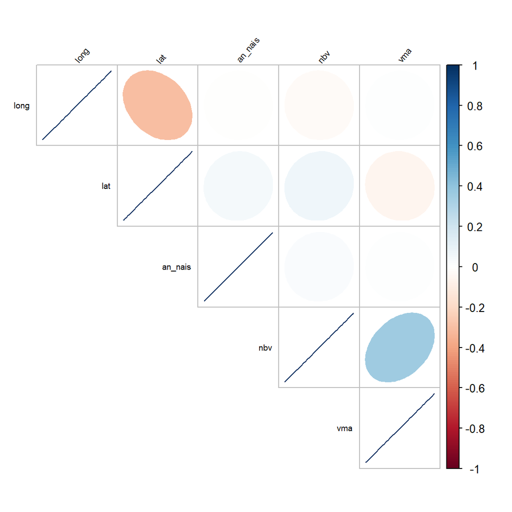

```r
corrplot(correlation, method ="ellipse", type="upper", order="AOE", tl.col="black", tl.srt=50, tl.cex = 0.6)
```

> **Pas de fortes correlations entre les variables.**

**Variables catégorielles**

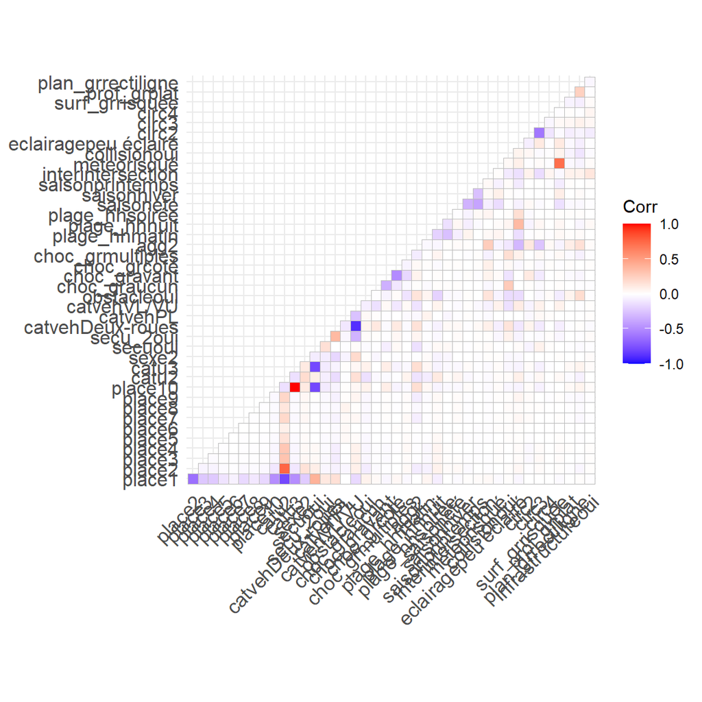

```r
model.matrix(~0+., data=train[,cat_vars]) %>%
  cor(use="pairwise.complete.obs") %>%
  ggcorrplot(show.diag=FALSE, type="lower", lab=FALSE, lab_size=0)
```

> **Dans l’ensemble les variables sont pas très corrélées.**

## Scaling

```r
center_scale <- caret::preProcess(train, method = c("center", "scale"))
center_scale
```

```
## Created from 90365 samples and 26 variables
##
## Pre-processing:
##   - centered (5)
##   - ignored (21)
##   - scaled (5)
```

```r
train_scaled <- predict(center_scale, train)
test_scaled <- predict(center_scale, test)
```

> **Numerical variables are centered and scaled.**

## Dummy var

```r
dummies <- dummyVars(grav ~ ., data = train_scaled)

train_scaled_dum <- predict(dummies, newdata = train_scaled) %>%
  data.frame()

test_scaled_dum <- predict(dummies, newdata = test_scaled) %>%
  data.frame()

train_scaled_dum$grav <- train$grav
test_scaled_dum$grav <- test$grav
```

> **We create dummy variables for each categorical variables. Except target.**

```r
train_scaled_dum %>% str()
```

```
## 'data.frame':    90365 obs. of  66 variables:
##  $ place.1                : num  1 1 1 0 1 1 1 1 1 1 ...
##  $ place.2                : num  0 0 0 0 0 0 0 0 0 0 ...
##  $ place.3                : num  0 0 0 0 0 0 0 0 0 0 ...
##  $ place.4                : num  0 0 0 0 0 0 0 0 0 0 ...
##  $ place.5                : num  0 0 0 0 0 0 0 0 0 0 ...
##  $ place.6                : num  0 0 0 0 0 0 0 0 0 0 ...
##  $ place.7                : num  0 0 0 1 0 0 0 0 0 0 ...
##  $ place.8                : num  0 0 0 0 0 0 0 0 0 0 ...
##  $ place.9                : num  0 0 0 0 0 0 0 0 0 0 ...
##  $ place.10               : num  0 0 0 0 0 0 0 0 0 0 ...
##  $ catu.1                 : num  1 1 1 0 1 1 1 1 1 1 ...
##  $ catu.2                 : num  0 0 0 1 0 0 0 0 0 0 ...
##  $ catu.3                 : num  0 0 0 0 0 0 0 0 0 0 ...
##  $ sexe.1                 : num  0 1 1 0 1 1 1 1 1 1 ...
```

[output cut: 52 more lines]

```r
test_scaled_dum %>% str()
```

```
## 'data.frame':    38728 obs. of  66 variables:
##  $ place.1                : num  1 1 1 1 0 1 1 1 1 0 ...
##  $ place.2                : num  0 0 0 0 0 0 0 0 0 0 ...
##  $ place.3                : num  0 0 0 0 0 0 0 0 0 0 ...
##  $ place.4                : num  0 0 0 0 0 0 0 0 0 1 ...
##  $ place.5                : num  0 0 0 0 0 0 0 0 0 0 ...
##  $ place.6                : num  0 0 0 0 0 0 0 0 0 0 ...
##  $ place.7                : num  0 0 0 0 0 0 0 0 0 0 ...
##  $ place.8                : num  0 0 0 0 0 0 0 0 0 0 ...
##  $ place.9                : num  0 0 0 0 0 0 0 0 0 0 ...
##  $ place.10               : num  0 0 0 0 1 0 0 0 0 0 ...
##  $ catu.1                 : num  1 1 1 1 0 1 1 1 1 0 ...
##  $ catu.2                 : num  0 0 0 0 0 0 0 0 0 1 ...
##  $ catu.3                 : num  0 0 0 0 1 0 0 0 0 0 ...
##  $ sexe.1                 : num  1 1 1 1 0 1 0 1 0 0 ...
```

[output cut: 52 more lines]

## Saving

```r
train_dtypes <- train_scaled_dum %>% get_dtypes()
write.csv2(train_scaled_dum, 'train.csv', row.names=FALSE)
write.csv2(train_dtypes, 'train_dtypes.csv', row.names=FALSE)

test_dtypes <- test_scaled_dum %>% get_dtypes()
write.csv2(test_scaled_dum, 'test.csv', row.names=FALSE)
write.csv2(test_dtypes, 'test_dtypes.csv', row.names=FALSE)
```

# Model

## Acquisition

```r
train_dtypes <- read.csv2(
  'train_dtypes.csv',
  header=TRUE,
  sep=';'
)
original_train <- read.csv2(
  'train.csv',
  header=TRUE,
  sep=';',
  colClasses=set_dtypes_df(train_dtypes)
)

test_dtypes <- read.csv2(
  'test_dtypes.csv',
  header=TRUE,
  sep=';'
)
original_test <- read.csv2(
  'test.csv',
  header=TRUE,
  sep=';',
  colClasses=set_dtypes_df(test_dtypes)
)

train <- original_train
test <- original_test
```

```r
train %>% get_missing()
```

```
##                                        variable   dtype count unique missing
## place.1                                 place.1 numeric 90365      2       0
## place.2                                 place.2 numeric 90365      2       0
## place.3                                 place.3 numeric 90365      2       0
## place.4                                 place.4 numeric 90365      2       0
## place.5                                 place.5 numeric 90365      2       0
## place.6                                 place.6 numeric 90365      2       0
## place.7                                 place.7 numeric 90365      2       0
## place.8                                 place.8 numeric 90365      2       0
## place.9                                 place.9 numeric 90365      2       0
## place.10                               place.10 numeric 90365      2       0
## catu.1                                   catu.1 numeric 90365      2       0
## catu.2                                   catu.2 numeric 90365      2       0
## catu.3                                   catu.3 numeric 90365      2       0
## sexe.1                                   sexe.1 numeric 90365      2       0
## sexe.2                                   sexe.2 numeric 90365      2       0
## an_nais                                 an_nais numeric 90365    101       0
## secu.non                               secu.non numeric 90365      2       0
## secu.oui                               secu.oui numeric 90365      2       0
## secu_2.non                           secu_2.non numeric 90365      2       0
## secu_2.oui                           secu_2.oui numeric 90365      2       0
## catveh.Autres                     catveh.Autres numeric 90365      2       0
## catveh.Deux.roues             catveh.Deux.roues numeric 90365      2       0
## catveh.PL                             catveh.PL numeric 90365      2       0
## catveh.VL.VU                       catveh.VL.VU numeric 90365      2       0
## obstacle.non                       obstacle.non numeric 90365      2       0
## obstacle.oui                       obstacle.oui numeric 90365      2       0
## choc_gr.arriere                 choc_gr.arriere numeric 90365      2       0
## choc_gr.aucun                     choc_gr.aucun numeric 90365      2       0
## choc_gr.avant                     choc_gr.avant numeric 90365      2       0
## choc_gr.coté                       choc_gr.coté numeric 90365      2       0
## choc_gr.multiples             choc_gr.multiples numeric 90365      2       0
## agg.1                                     agg.1 numeric 90365      2       0
## agg.2                                     agg.2 numeric 90365      2       0
## lat                                         lat numeric 90365     11       0
## long                                       long numeric 90365     15       0
## plage_hh.apres.midi         plage_hh.apres.midi numeric 90365      2       0
## plage_hh.matin                   plage_hh.matin numeric 90365      2       0
## plage_hh.nuit                     plage_hh.nuit numeric 90365      2       0
## plage_hh.soirée                 plage_hh.soirée numeric 90365      2       0
```

[output cut: 79 more lines]

```
## circ.1                             0
## circ.2                             0
## circ.3                             0
## circ.4                             0
## nbv                                0
## vma                                0
## surf_gr.normale                    0
## surf_gr.risquée                    0
## prof_gr.pente.cote                 0
## prof_gr.plat                       0
## plan_gr.courbe                     0
## plan_gr.rectiligne                 0
## infrastructure.non                 0
## infrastructure.oui                 0
## grav                               0
```

## Modeling

```r
fitControl <- trainControl(method = "cv",
                           number = 10)
```

### Tree

**Model**

```r
model <- rpart(grav ~ ., data = train)

pred <- predict(model, newdata = test, type = "class")
confusionMatrix(pred, test$grav)
```

```
## Confusion Matrix and Statistics
##
##           Reference
## Prediction     1     2     3     4
##          1 12285   186   893  4228
##          2     0     0     0     0
##          3     0     0     0     0
##          4  4191   769  4862 11314
##
## Overall Statistics
##
##                Accuracy : 0.6094
##                  95% CI : (0.6045, 0.6142)
##     No Information Rate : 0.4254
##     P-Value [Acc > NIR] : < 2.2e-16
##
##                   Kappa : 0.3353
##
##  Mcnemar's Test P-Value : NA
##
## Statistics by Class:
##
##                      Class: 1 Class: 2 Class: 3 Class: 4
## Sensitivity            0.7456  0.00000   0.0000   0.7280
## Specificity            0.7615  1.00000   1.0000   0.5764
## Pos Pred Value         0.6983      NaN      NaN   0.5353
## Neg Pred Value         0.8017  0.97534   0.8514   0.7597
## Prevalence             0.4254  0.02466   0.1486   0.4013
## Detection Rate         0.3172  0.00000   0.0000   0.2921
## Detection Prevalence   0.4542  0.00000   0.0000   0.5458
## Balanced Accuracy      0.7536  0.50000   0.5000   0.6522
```

**Cross validation**

```r
set.seed(2023)
n_folds <- 10

folds <- createFolds(train$grav, k = n_folds,
                     list = TRUE,
                     returnTrain = FALSE)

cv_results <- data.frame(accuracy = numeric(n_folds))

for (i in 1:n_folds) {

  train_fold <- train[-folds[[i]], ]
  validation_fold <- train[folds[[i]], ]

  model_fold <- rpart(grav ~ ., data = train_fold)

  pred_fold <- predict(model_fold, newdata = validation_fold, type = "class")

  cv_results[i, "accuracy"] <-
    sum(pred_fold == validation_fold$grav) / nrow(validation_fold)
}

print(cv_results)
```

```
##     accuracy
## 1  0.6171979
## 2  0.6096050
## 3  0.6045148
## 4  0.6123285
## 5  0.6024563
## 6  0.6115538
## 7  0.6098938
## 8  0.6169341
## 9  0.6109328
## 10 0.6051787
```

```r
cat("Accuracy (mean +/- sd): ",
    mean(cv_results$accuracy),
    " +/- ",
    sd(cv_results$accuracy),
    "\n")
```

```
## Accuracy (mean +/- sd):  0.6100596  +/-  0.004932543
```

```r
confusionMatrix(pred, test$grav)
```

```
## Confusion Matrix and Statistics
##
##           Reference
## Prediction     1     2     3     4
##          1 12285   186   893  4228
##          2     0     0     0     0
##          3     0     0     0     0
##          4  4191   769  4862 11314
##
## Overall Statistics
##
##                Accuracy : 0.6094
##                  95% CI : (0.6045, 0.6142)
##     No Information Rate : 0.4254
##     P-Value [Acc > NIR] : < 2.2e-16
##
##                   Kappa : 0.3353
##
##  Mcnemar's Test P-Value : NA
##
## Statistics by Class:
##
##                      Class: 1 Class: 2 Class: 3 Class: 4
## Sensitivity            0.7456  0.00000   0.0000   0.7280
## Specificity            0.7615  1.00000   1.0000   0.5764
## Pos Pred Value         0.6983      NaN      NaN   0.5353
## Neg Pred Value         0.8017  0.97534   0.8514   0.7597
## Prevalence             0.4254  0.02466   0.1486   0.4013
## Detection Rate         0.3172  0.00000   0.0000   0.2921
## Detection Prevalence   0.4542  0.00000   0.0000   0.5458
## Balanced Accuracy      0.7536  0.50000   0.5000   0.6522
```

### Random forest

```r
set.seed(2023)

rf <- caret::train(grav ~ .,
                   data = train,
                   method = "rf",
                   trControl = fitControl,
                   ntree = 10
                   )
rf
```

```
## Random Forest
##
## 90365 samples
##    65 predictor
##     4 classes: '1', '2', '3', '4'
##
## No pre-processing
## Resampling: Cross-Validated (10 fold)
## Summary of sample sizes: 81328, 81329, 81329, 81329, 81327, 81328, ...
## Resampling results across tuning parameters:
##
##   mtry  Accuracy   Kappa
##    2    0.6053671  0.3349430
##   33    0.6109556  0.3745489
##   65    0.6052232  0.3664230
##
## Accuracy was used to select the optimal model using the largest value.
## The final value used for the model was mtry = 33.
```

```r
varImp(rf)
```

```
## rf variable importance
##
##   only 20 most important variables shown (out of 65)
##
##                     Overall
## an_nais             100.000
## long                 42.264
## catveh.Deux.roues    41.945
## lat                  37.252
## nbv                  27.687
## vma                  24.296
## place.1              17.635
## obstacle.oui         14.666
## catveh.VL.VU         12.105
## saison.printemps     10.155
## saison.été           10.106
## plage_hh.apres.midi  10.050
## saison.automne        9.891
## plage_hh.matin        9.409
## saison.hiver          9.202
## agg.2                 8.830
## circ.2                8.727
## choc_gr.avant         8.176
## plage_hh.soirée       7.550
## catu.3                7.536
```

```r
train_pred <- predict(rf, newdata = train)
confusionMatrix(train_pred, train$grav)
```

```
## Confusion Matrix and Statistics
##
##           Reference
## Prediction     1     2     3     4
##          1 38175    34   188   957
##          2     2  2134    10    11
##          3    51    50 12816   181
##          4   404    46   316 34990
##
## Overall Statistics
##
##                Accuracy : 0.9751
##                  95% CI : (0.9741, 0.9761)
##     No Information Rate : 0.4275
##     P-Value [Acc > NIR] : < 2.2e-16
##
##                   Kappa : 0.9607
##
##  Mcnemar's Test P-Value : < 2.2e-16
##
## Statistics by Class:
##
##                      Class: 1 Class: 2 Class: 3 Class: 4
## Sensitivity            0.9882  0.94258   0.9614   0.9682
## Specificity            0.9772  0.99974   0.9963   0.9859
## Pos Pred Value         0.9700  0.98934   0.9785   0.9786
## Neg Pred Value         0.9910  0.99853   0.9933   0.9790
## Prevalence             0.4275  0.02505   0.1475   0.3999
## Detection Rate         0.4225  0.02362   0.1418   0.3872
## Detection Prevalence   0.4355  0.02387   0.1449   0.3957
## Balanced Accuracy      0.9827  0.97116   0.9789   0.9770
```

```r
test_pred <- predict(rf, newdata = test)
confusionMatrix(test_pred, test$grav)
```

```
## Confusion Matrix and Statistics
##
##           Reference
## Prediction     1     2     3     4
##          1 12380   181   995  4650
##          2    59    94   142   102
##          3   584   339  2018  1765
##          4  3453   341  2600  9025
##
## Overall Statistics
##
##                Accuracy : 0.6072
##                  95% CI : (0.6024, 0.6121)
##     No Information Rate : 0.4254
##     P-Value [Acc > NIR] : < 2.2e-16
##
##                   Kappa : 0.3685
##
##  Mcnemar's Test P-Value : < 2.2e-16
##
## Statistics by Class:
##
##                      Class: 1 Class: 2 Class: 3 Class: 4
## Sensitivity            0.7514 0.098429  0.35065   0.5807
## Specificity            0.7382 0.991978  0.91848   0.7242
## Pos Pred Value         0.6800 0.236776  0.42881   0.5853
## Neg Pred Value         0.8004 0.977538  0.89016   0.7204
## Prevalence             0.4254 0.024659  0.14860   0.4013
## Detection Rate         0.3197 0.002427  0.05211   0.2330
## Detection Prevalence   0.4701 0.010251  0.12151   0.3981
## Balanced Accuracy      0.7448 0.545204  0.63457   0.6525
```

### Linear Discriminant Analysis

```r
set.seed(2023)

lda <- caret::train(grav ~ ., data = train,
                 method = "lda",
                 trControl = fitControl,
                 )
lda
```

```
## Linear Discriminant Analysis
##
## 90365 samples
##    65 predictor
##     4 classes: '1', '2', '3', '4'
##
## No pre-processing
## Resampling: Cross-Validated (10 fold)
## Summary of sample sizes: 81328, 81329, 81329, 81329, 81327, 81328, ...
## Resampling results:
##
##   Accuracy   Kappa
##   0.6291817  0.3906339
```

```r
varImp(lda)
```

```
## ROC curve variable importance
##
##   variables are sorted by maximum importance across the classes
##   only 20 most important variables shown (out of 65)
##
##                             X1    X2    X3     X4
## catveh.Deux.roues       100.00 78.60 68.21 100.00
## catveh.VL.VU             88.20 66.96 62.16  88.20
## obstacle.non             81.49 81.49 81.49  51.24
## obstacle.oui             81.49 81.49 81.49  51.24
## agg.1                    73.84 73.84 73.84  45.59
## agg.2                    73.84 73.84 73.84  45.59
## vma                      72.49 72.49 72.49  38.18
## secu.non                 61.68 61.68 61.68  43.53
## secu.oui                 61.68 61.68 61.68  43.53
## inter.Hors.intersection  45.79 45.79 45.79  20.38
## inter.intersection       45.79 45.79 45.79  20.38
## an_nais                  43.06 43.06 44.36  35.02
## circ.2                   43.28 38.08 38.08  43.28
## place.1                  36.40 42.98 34.26  42.98
## catu.1                   36.15 42.36 34.41  42.36
## choc_gr.arriere          37.43 37.43 37.43  33.80
## plan_gr.courbe           35.45 35.45 35.45  32.20
## plan_gr.rectiligne       35.45 35.45 35.45  32.20
## eclairage.peu.éclairé    34.65 34.65 34.65  13.44
## eclairage.éclairé        34.65 34.65 34.65  13.44
```

```r
train_pred <- predict(lda, newdata = train)
confusionMatrix(train_pred, train$grav)
```

```
## Confusion Matrix and Statistics
##
##           Reference
## Prediction     1     2     3     4
##          1 32352   510  2668 12603
##          2    92   225   388   213
##          3   546   697  3362  2315
##          4  5642   832  6912 21008
##
## Overall Statistics
##
##                Accuracy : 0.6302
##                  95% CI : (0.627, 0.6333)
##     No Information Rate : 0.4275
##     P-Value [Acc > NIR] : < 2.2e-16
##
##                   Kappa : 0.3923
##
##  Mcnemar's Test P-Value : < 2.2e-16
##
## Statistics by Class:
##
##                      Class: 1 Class: 2 Class: 3 Class: 4
## Sensitivity            0.8374  0.09938  0.25221   0.5813
## Specificity            0.6950  0.99213  0.95381   0.7531
## Pos Pred Value         0.6721  0.24510  0.48584   0.6108
## Neg Pred Value         0.8513  0.97720  0.88054   0.7297
## Prevalence             0.4275  0.02505  0.14751   0.3999
## Detection Rate         0.3580  0.00249  0.03720   0.2325
## Detection Prevalence   0.5327  0.01016  0.07658   0.3806
## Balanced Accuracy      0.7662  0.54576  0.60301   0.6672
```

```r
test_pred <- predict(lda, newdata = test)
confusionMatrix(test_pred, test$grav)
```

```
## Confusion Matrix and Statistics
##
##           Reference
## Prediction     1     2     3     4
##          1 13772   228  1155  5602
##          2    53    79   176    72
##          3   272   317  1427   993
##          4  2379   331  2997  8875
##
## Overall Statistics
##
##                Accuracy : 0.6237
##                  95% CI : (0.6188, 0.6285)
##     No Information Rate : 0.4254
##     P-Value [Acc > NIR] : < 2.2e-16
##
##                   Kappa : 0.3821
##
##  Mcnemar's Test P-Value : < 2.2e-16
##
## Statistics by Class:
##
##                      Class: 1 Class: 2 Class: 3 Class: 4
## Sensitivity            0.8359 0.082723  0.24796   0.5710
## Specificity            0.6861 0.992031  0.95202   0.7539
## Pos Pred Value         0.6635 0.207895  0.47424   0.6086
## Neg Pred Value         0.8495 0.977157  0.87883   0.7239
## Prevalence             0.4254 0.024659  0.14860   0.4013
## Detection Rate         0.3556 0.002040  0.03685   0.2292
## Detection Prevalence   0.5360 0.009812  0.07770   0.3765
## Balanced Accuracy      0.7610 0.537377  0.59999   0.6624
```

# Conclusion

La nature des données - présence de nombreuse variables catégorielles - nous a mené vers l’utilisation de modèles à base d’arbres et des méthodes de discriminations. Malheureusement ces modèles ne sont pas toujours facilement interprétables contrairement à des modèles plus classiques. Ils permettent en particulier d’avoir des informations sur l’imortance des variables explicatives dans la discrimination.

La variable cible avait peu de représentants dans certaines modalités. Cela a pu entrainer des sous-représentations de ces catégories pendant la prédictions. Notamment la classification par arbre n’a su prédire aucune des variables sous-représentées.